# Hito2_V1

Grupo 9

7-12-2020

```r
#install.packages("dplyr")
#install.packages("data.table")
#install.packages("readxlsb")
#install.packages("qdapTools")
#install.packages("FactoMineR")
#install.packages("factoextra")
```

# Hito2 Grupo 9 - Proyecto: **A donde van**

Integrantes: Joaquin Cubelli de Leon, Luckas Diaz Renjifo, Ricardo Lopez Diaz, José Luis Romero y Andres Urrutia Aliaga.

# Introducción

Para este trabajo se utilizaran datos realacionados con el sistema de transporte público metropolitano, en particular las “Matrices de Viajes” relacionado al origen-destino, subida y bajada, recolectadas a partir de software ADATRAP. Esta información fue obtenida de las bases de datos de la tarjeta bip! y de los GPS de los buses.

En estas “Matrices” se tienen 3 tipos de datasets desde el año 2014 al 2019, mientras que para los años 2011 a 2013 se tienen algunos de estos 3 tipos:

-Tabla de viajes: Cada fila de la base de datos, corresponde a un viaje realizado por una persona, en donde es estimado el lugar de subida y bajada de cada etapa de viajes. Se incluyen archivos que detallan los campos y estructuras de las tablas. -Tabla de etapas: Es un extracto de la Tabla de Viajes, donde cada fila de la base de datos corresponde a una etapa del viaje realizado por una persona, en donde es estimado el lugar de subida y bajada de la etapa. Se incluyen archivos que detallan los campos y estructuras de las tablas. -Tablas agregadas de matrices OD, subidas y bajadas. Contienen un resumen de la información de las tablas de viajes y etapas.

Por otra parte, se ocupará la información recopilada el año 2012 mediante la “Encuesta de Origen y Destino de Viajes Santiago 2012”, la cual consistió en encuestar a todos los residentes de 18.000 hogares del Gran Santiago, seleccionados aleatoriamente, en el periodo comprendido entre julio de 2012 y noviembre de 2013.

**Motivación**: nuestra vision sobre el sistema transporte en la gran capital es que existen largas horas de viajes, grandes congestiones de larga duración, deficiencia en la frecuencia de los buses y un descontento generalizado por parte de los usuarios. Esto nos lleva a estudiar estos datos ya que se podría dar pie a mejoras graduales en el sistema de transporte como tal (de las cuales varias que propongamos ya esten probablemente implementadas) como por ejemplo, reforzar el servicio de buses para complementar viajes en horas punta, posiblemente disminuyendo los tiempos de viaje.

Paginas de los datasets:

- http://www.dtpm.gob.cl/index.php/documentos/matrices-de-viaje
- https://datos.gob.cl/dataset/31616

**Presentacion**

- https://youtu.be/Qb-9ax1tYVc

# Exploración de datos

La exploración de los datos se hicieron sobre la matriz de viaje del año 2019 y la tabla de viajes del año 2020, ya que para los datos de otros años seria repetir lo presentado en esta sección.

## Definir directorio a trabajar:

```r
# Asignamos nuestro "working directory" (set w. d.) como el directorio ~/RDATA
setwd(choose.dir())
#setwd("D:/UdeChile/12Semestre/Intro Mineria/Proyecto/Datos2019")
```

Otra opcion es ir a “Session”->“Set Working Directory”->“Chooose Directory” para elegir el directorio.

## Cargar remotamente los datos:

```r
#temp <- tempfile()
#download.file("http://www.dtpm.gob.cl/descargas/tablas/tabla-viajes.rar",
#              temp)
#con <- unz(temp, "gbr_Country_en_csv_v2.csv")
#dat <- read.table(con, header=T, skip=2, sep=",")
#unlink(temp)
```

## Cargar los datos de forma local:

Para cargar los datos de forma local, se debe clonar el proyecto desde el repositorio de github, donde se tiene la carpeta ‘datos’ que contiene todos los archivos que se cargar.

Al dataset ‘viajeslaboral_2020’ se le aplico un sample anterior a cargarlo a rstudio, ya que consistia en un archivo de caso 10gb de información.

```r
library(readr)

loc <- locale("es", decimal_mark = ',', encoding = 'latin1')

# 2020
viajeslaboral_2020 <- read_csv2('datos/viajes2020_03_laboral_100k.csv', locale = loc, na = c('-', 'NA'), guess_max = 10000)
# 2019
matriz_2019.08 <- read_csv2('datos/2019Agosto_05_09.MatrizODviajes_comunas_mediahora.csv', locale = loc, na = c('-', 'NA'))
#subidas_2019.08 <- read_csv2('datos/2019Agosto_05_09.SubidasPorParadaMediaHora.csv', locale = loc, na = c('-', 'NA'))
#matriz_2019.04 <- read_csv2('datos/tablasWeb2019Abril_01_05.MatrizODComunasMediaHora.csv', locale = loc)
#subidas_2019.04 <- read_csv2('datos/tablasWeb2019Abril_01_05.SubidasPorParadaMediaHora.csv', locale = loc, na = c('-', 'NA'))

# 2018
#matriz_2018.10 <- read_csv2('datos/tablasWeb2018Oct_08_12.MatrizODComunasMediaHora.csv', locale = loc)
#subidas_2018.10 <- read_csv2('datos/tablasWeb2018Oct_08_12.SubidasPorParadaMediaHora.csv', locale = loc, na = c('-', 'NA'))
matriz_2018.04 <- read.csv2('datos/2018abril_09_13.MatrizODviajes_comunas_mediahora.csv', sep = '|', na = c('-', 'NA'))
#subidas_2018.04 <- read.csv2('datos/2018abril_09_13.Subidas_paradero_mediahora.csv', na = c('-', 'NA'), sep = '|')

# 2017
matriz_2017.04 <- read.csv2('datos/2017abril_(3.4.6.7.12).MatrizODviajes_comunas_mediahora.csv', sep = '|', na = c('-', 'NA'))
#subidas_2017.04 <- read.csv2('datos/2017abril_(3.4.6.7.12).Subidas_paradero_mediahora.csv', sep = '|', na = c('-', 'NA'))

# 2016
matriz_2016.05 <- read.csv2('datos/2016mayo_23_27.MatrizODviajes_comunas_mediahora.csv', sep = '|', na = c('-', 'NA'))
#subidas_2016.05 <- read.csv2('datos/2016mayo_23_27.Subidas_paradero_mediahora.csv', sep = '|', na = c('-', 'NA'))

# 2015
matriz_2015.04 <- read.csv2('datos/2015abril_20_24.MatrizODviajes_comunas_mediahora.csv', sep = '|', na = c('-', 'NA'))
#subidas_2015.04 <- read.csv2('datos/2015abril_20_24.Subidas_paradero_mediahora.csv', sep = '|', na = c('-', 'NA'))

# 2014
matriz_2014.05 <- read.csv2('datos/2014mayo_26_30.MatrizODviajes_comunas_mediahora.csv', sep = '|', na = c('-', 'NA'))
#subidas_2014.05 <- read.csv2('datos/2014mayo_26_30.Subidas_paradero_mediahora.csv', sep = '|', na = c('-', 'NA'))

# 2013
matriz_2013.04 <- read.csv2('datos/2013abril_15_19.MatrizODviajes_comunas_mediahora.csv', sep = '|', na = c('-', 'NA'))
#subidas_2013.04 <- read.csv2('datos/2013abril_15_19.Subidas_paradero_mediahora.csv', sep = '|', na = c('-', 'NA'))

# 2012
matriz_2012.04 <- read.csv2('datos/2012abril_16_20.MatrizODviajes_comunas_mediahora.csv', sep = '|', na = c('-', 'NA'))
#subidas_2012.04 <- read.csv2('datos/2012abril_16_20.Subidas_paradero_mediahora.csv', sep = '|', na = c('-', 'NA'))

# 2011
matriz_2011.04 <- read.csv2('datos/2011abril_11_15.MatrizODviajes_comunas_mediahora.csv', sep = '|', na = c('-', 'NA'))


# Encuesta
viajes_encuesta <- read_csv2('datos/viajes.csv', locale = loc)
hogares_encuesta <- read_csv2('datos/Hogares.csv', locale = loc)
personas_encuesta <- read_csv2('datos/personas.csv', locale = loc)
comunas_encuesta <- read_csv2('datos/Comuna.csv', locale = loc)
propositos_encuesta <- read_csv2('datos/Proposito.csv', locale = loc)
tipodia_encuesta <- read_csv2('datos/TipoDia.csv', locale = loc)
sexo_encuesta <- read_csv2('datos/Sexo.csv', locale = loc)
adultomayor_encuesta <- read_csv2('datos/AdultoMayor.csv', locale = loc)
estudios_encuesta <- read_csv2('datos/Estudios.csv', locale = loc)
```

## Atributos del dataset matriz_2019.08:

```r
library(dplyr)
# select character columns 'char1', 'char2', etc. to factor:
matriz_2019.08 <- mutate_at(matriz_2019.08, vars('ComunaSubida', 'ComunaBajada'), as.factor)

str(matriz_2019.08)
```

```
## tibble [44,660 x 12] (S3: spec_tbl_df/tbl_df/tbl/data.frame)
##  $ ComunaSubida        : Factor w/ 34 levels "CERRILLOS","CERRO NAVIA",..: 18 18 18 18 18 18 18 18 18 18 ...
##  $ ComunaBajada        : Factor w/ 34 levels "CERRILLOS","CERRO NAVIA",..: 18 23 5 16 2 25 19 13 15 1 ...
##  $ MediaHora           : 'hms' num [1:44660] 00:00:00 00:00:00 00:00:00 00:00:00 ...
##   ..- attr(*, "units")= chr "secs"
##  $ ViajeLaboralPromedio: num [1:44660] 102.987 0.372 7.064 0.744 0.372 ...
##  $ Viajes1Etapa        : num [1:44660] 95.923 0.372 5.949 0 0 ...
##  $ Viajes2Etapas       : num [1:44660] 7.064 0 1.115 0.744 0.372 ...
##  $ Viajes3Etapas       : num [1:44660] 0 0 0 0 0 0 0 0 0 0 ...
##  $ Viajes4Etapas       : num [1:44660] 0 0 0 0 0 0 0 0 0 0 ...
##  $ Viajes5oMasEtapas   : num [1:44660] 0 0 0 0 0 0 0 0 0 0 ...
##  $ ViajesUsanMetro     : num [1:44660] 0 0 0 0 0 0 0 0 0 0 ...
##  $ ViajesSoloMetro     : num [1:44660] 0 0 0 0 0 0 0 0 0 0 ...
##  $ ViajesSoloBus       : num [1:44660] 102.987 0.372 7.064 0.744 0.372 ...
##  - attr(*, "spec")=
##   .. cols(
##   ..   ComunaSubida = col_character(),
##   ..   ComunaBajada = col_character(),
##   ..   MediaHora = col_time(format = ""),
##   ..   ViajeLaboralPromedio = col_double(),
##   ..   Viajes1Etapa = col_double(),
##   ..   Viajes2Etapas = col_double(),
##   ..   Viajes3Etapas = col_double(),
##   ..   Viajes4Etapas = col_double(),
##   ..   Viajes5oMasEtapas = col_double(),
##   ..   ViajesUsanMetro = col_double(),
##   ..   ViajesSoloMetro = col_double(),
##   ..   ViajesSoloBus = col_double()
##   .. )
```

```r
summary(matriz_2019.08)
```

```
##            ComunaSubida             ComunaBajada    MediaHora
##  SANTIAGO        : 1591   SANTIAGO        : 1523   Length:44660
##  PROVIDENCIA     : 1483   ESTACION CENTRAL: 1385   Class1:hms
##  LAS CONDES      : 1433   PROVIDENCIA     : 1378   Class2:difftime
##  NUNOA           : 1426   LAS CONDES      : 1362   Mode  :numeric
##  ESTACION CENTRAL: 1374   LA FLORIDA      : 1360
##  MAIPU           : 1370   NUNOA           : 1355
##  (Other)         :35983   (Other)         :36297
##  ViajeLaboralPromedio  Viajes1Etapa      Viajes2Etapas      Viajes3Etapas
##  Min.   :   0.201     Min.   :   0.000   Min.   :   0.000   Min.   :  0.000
##  1st Qu.:   4.388     1st Qu.:   0.278   1st Qu.:   1.938   1st Qu.:  0.291
##  Median :  16.314     Median :   4.868   Median :   6.537   Median :  1.147
##  Mean   :  97.578     Mean   :  70.733   Mean   :  23.504   Mean   :  3.258
##  3rd Qu.:  61.546     3rd Qu.:  33.478   3rd Qu.:  19.607   3rd Qu.:  3.161
##  Max.   :8220.357     Max.   :7906.244   Max.   :2402.393   Max.   :304.960
##
##  Viajes4Etapas     Viajes5oMasEtapas  ViajesUsanMetro    ViajesSoloMetro
##  Min.   :0.00000   Min.   :0.000000   Min.   :   0.000   Min.   :   0.00
##  1st Qu.:0.00000   1st Qu.:0.000000   1st Qu.:   1.694   1st Qu.:   0.00
##  Median :0.00000   Median :0.000000   Median :   8.772   Median :   0.00
##  Mean   :0.07656   Mean   :0.006051   Mean   :  66.308   Mean   :  45.18
##  3rd Qu.:0.00000   3rd Qu.:0.000000   3rd Qu.:  36.038   3rd Qu.:  14.51
##  Max.   :6.46100   Max.   :1.254000   Max.   :5359.305   Max.   :5181.31
##
##  ViajesSoloBus
##  Min.   :   0.000
##  1st Qu.:   0.595
##  Median :   2.751
##  Mean   :  31.270
##  3rd Qu.:  15.027
##  Max.   :3624.576
##
```

```r
head(matriz_2019.08,10)
```

```
## # A tibble: 10 x 12
##    ComunaSubida ComunaBajada MediaHora ViajeLaboralPro~ Viajes1Etapa
##    <fct>        <fct>        <time>               <dbl>        <dbl>
##  1 MAIPU        MAIPU        00'00"             103.          95.9
##  2 MAIPU        PUDAHUEL     00'00"               0.372        0.372
##  3 MAIPU        ESTACION CE~ 00'00"               7.06         5.95
##  4 MAIPU        LO PRADO     00'00"               0.744        0
##  5 MAIPU        CERRO NAVIA  00'00"               0.372        0
##  6 MAIPU        QUILICURA    00'00"               0.372        0
##  7 MAIPU        NUNOA        00'00"               0.372        0.372
##  8 MAIPU        LAS CONDES   00'00"               0.744        0.372
##  9 MAIPU        LO ESPEJO    00'00"               0.372        0.372
## 10 MAIPU        CERRILLOS    00'00"               1.86         1.86
## # ... with 7 more variables: Viajes2Etapas <dbl>, Viajes3Etapas <dbl>,
## #   Viajes4Etapas <dbl>, Viajes5oMasEtapas <dbl>, ViajesUsanMetro <dbl>,
## #   ViajesSoloMetro <dbl>, ViajesSoloBus <dbl>
```

**Datos NA**:

```r
sapply(matriz_2019.08, function(x) sum(is.na(x)))
```

```
##         ComunaSubida         ComunaBajada            MediaHora
##                    0                    0                    0
## ViajeLaboralPromedio         Viajes1Etapa        Viajes2Etapas
##                    0                    0                    0
##        Viajes3Etapas        Viajes4Etapas    Viajes5oMasEtapas
##                    0                    0                    0
##      ViajesUsanMetro      ViajesSoloMetro        ViajesSoloBus
##                    0                    0                    0
```

No se encontraron datos NA.

**Datos 0**:

```r
sapply(matriz_2019.08, function(x) sum(x==0))
```

```
##         ComunaSubida         ComunaBajada            MediaHora
##                    0                    0                  535
## ViajeLaboralPromedio         Viajes1Etapa        Viajes2Etapas
##                    0                10729                 2728
##        Viajes3Etapas        Viajes4Etapas    Viajes5oMasEtapas
##                 8301                36802                43742
##      ViajesUsanMetro      ViajesSoloMetro        ViajesSoloBus
##                 4900                22967                 4842
```

Con lo anterior se aprecia que las columnas “Viajes4Etapas” y “Viajes5oMasEtapas” poseen gran cantidad de valores 0, teniendo en cuenta que el dataset consta de 44660 observaciones. Entonces estas columnas no se contemplaran. Luego hay que decidir sobre el resto de valores 0, ya que estos pueden ser reemplazados por un promedio de la columna o de alguna otra forma.

```r
# Se eliminan las columnas "Viajes4Etapas" y "Viajes5oMasEtapas"
matriz_2019.08$Viajes4Etapas <- NULL
matriz_2019.08$Viajes5oMasEtapas <- NULL
```

**Datos Negativos**:

```r
# se aplica solo a los datos numericos
sapply(matriz_2019.08[,4:10], function(x) sum(x<0))
```

```
## ViajeLaboralPromedio         Viajes1Etapa        Viajes2Etapas
##                    0                    0                    0
##        Viajes3Etapas      ViajesUsanMetro      ViajesSoloMetro
##                    0                    0                    0
##        ViajesSoloBus
##                    0
```

Lo anterior evidencia que no hay datos negativos que puedan afectar en algun analisis.

## Atributos dataset viajeslaboral_2020

```r
str(viajeslaboral_2020)
```

```
## tibble [100,007 x 107] (S3: spec_tbl_df/tbl_df/tbl/data.frame)
##  $ netapa                : chr [1:100007] "..." "1" "1" "2" ...
##  $ etapas                : logi [1:100007] NA NA NA NA NA NA ...
##  $ netapassinbajada      : num [1:100007] NA 1 0 1 0 1 0 0 0 0 ...
##  $ ultimaetapaconbajada  : num [1:100007] NA 0 1 0 1 0 1 1 1 1 ...
##  $ tviaje_seg            : num [1:100007] NA NA 1094 NA 0 ...
##  $ tviaje_min            : chr [1:100007] NA NA "18.2333" NA ...
##  $ dviajeeuclidiana_mts  : num [1:100007] NA NA 6.3e+07 NA 6.9e+05 ...
##  $ dviajeenruta_mts      : num [1:100007] NA NA 6521 NA 68 ...
##  $ paraderosubida        : chr [1:100007] NA "T-10-77-NS-15" "PEDRO DE VALDIVIA" "L-32-19-40-OP" ...
##  $ paraderobajada        : chr [1:100007] NA NA "QUINTA NORMAL" NA ...
##  $ comunasubida          : chr [1:100007] NA "PUDAHUEL" "PROVIDENCIA" "PENALOLEN" ...
##  $ comunabajada          : chr [1:100007] NA NA "SANTIAGO" NA ...
##  $ diseno777subida       : num [1:100007] NA 710 175 649 266 71 303 353 215 84 ...
##  $ diseno777bajada       : num [1:100007] NA NA 272 NA 307 NA 164 178 282 77 ...
##  $ tiemposubida          : POSIXct[1:100007], format:
```

```
## NA "2020-03-08 14:12:04" ...
##  $ tiempobajada          : POSIXct[1:100007], format: NA NA ...
##  $ periodosubida         : chr [1:100007] NA "05 - MEDIODIA DOMINGO" "04 - MANANA DOMINGO" "04 - MANANA DOMINGO" ...
##  $ periodobajada         : chr [1:100007] NA NA "04 - MANANA DOMINGO" NA ...
##  $ tipodia               : chr [1:100007] NA "DOMINGO" "DOMINGO" "DOMINGO" ...
##  $ mediahora             : 'hms' num [1:100007] NA 14:00:00 12:00:00 11:00:00 ...
##   ..- attr(*, "units")= chr "secs"
##  $ contrato              : logi [1:100007] NA NA NA NA NA NA ...
##  $ factorexpansion       : num [1:100007] NA 0 16933 0 15609 ...
##  $ tiempomediodeviaje    : POSIXct[1:100007], format: NA NA ...
##  $ periodomediodeviaje   : chr [1:100007] NA NA "04 - MANANA DOMINGO" NA ...
##  $ mediahoramediodeviaje : 'hms' num [1:100007] NA NA 12:30:00 NA ...
##   ..- attr(*, "units")= chr "secs"
##  $ tipodiamediodeviaje   : chr [1:100007] NA "DOMINGO" "DOMINGO" "DOMINGO" ...
##  $ t_1era_etapa          : chr [1:100007] NA NA "18.2333" "5.05" ...
##  $ d_1era_etapa          : num [1:100007] NA 0 6521 1009 68 ...
##  $ tespera_1era_etapa    : chr [1:100007] NA NA NA "9.758" ...
##  $ ttrasbordo_1era_etapa : chr [1:100007] NA NA NA "12.4833" ...
##  $ tcaminata_1era_etapa  : chr [1:100007] NA NA NA "2.7254" ...
##  $ dtransbordo_1era_etapa: num [1:100007] NA NA NA 2452835 NA ...
##  $ t_2da_etapa           : chr [1:100007] NA NA NA NA ...
##  $ d_2da_etapa           : num [1:100007] NA NA NA 0 NA NA NA NA NA NA ...
##  $ tespera_2da_etapa     : chr [1:100007] NA NA NA NA ...
##  $ ttrasbordo_2da_etapa  : chr [1:100007] NA NA NA NA ...
##  $ tcaminata_2da_etapa   : chr [1:100007] NA NA NA NA ...
##  $ dtransbordo_2da_etapa : num [1:100007] NA NA NA NA NA NA NA NA NA NA ...
##  $ t_3era_etapa          : chr [1:100007] NA NA NA NA ...
##  $ d_3era_etapa          : num [1:100007] NA NA NA NA NA NA NA NA NA NA ...
##  $ tespera_3era_etapa    : num [1:100007] NA NA NA NA NA NA NA NA NA NA ...
##  $ ttrasbordo_3era_etapa : num [1:100007] NA NA NA NA NA NA NA NA NA NA ...
##  $ tcaminata_3era_etapa  : chr [1:100007] NA NA NA NA ...
##  $ dtransbordo_3era_etapa: num [1:100007] NA NA NA NA NA NA NA NA NA NA ...
##  $ t_4ta_etapa           : num [1:100007] NA NA NA NA NA NA NA NA NA NA ...
##  $ d_4ta_etapa           : num [1:100007] NA NA NA NA NA NA NA NA NA NA ...
##  $ tespera_4ta_etapa     : logi [1:100007] NA NA NA NA NA NA ...
##  $ ttrasbordo_4ta_etapa  : logi [1:100007] NA NA NA NA NA NA ...
##  $ tcaminata_4ta_etapa   : logi [1:100007] NA NA NA NA NA NA ...
##  $ dtransbordo_4ta_etapa : logi [1:100007] NA NA NA NA NA NA ...
##  $ op_1era_etapa         : num [1:100007] NA 5 NA 5 NA NA 3 NA NA NA ...
##  $ op_2da_etapa          : num [1:100007] NA NA NA 2 NA NA NA NA NA NA ...
```

[output cut: 149 more lines]

```
##   ..   zona777bajada_4ta = col_double(),
##   ..   tipotransporte_1era = col_character(),
##   ..   tipotransporte_2da = col_character(),
##   ..   tipotransporte_3era = col_character(),
##   ..   tipotransporte_4ta = col_character(),
##   ..   tespera_1era = col_logical(),
##   ..   tespera_2da = col_logical(),
##   ..   tespera_3era = col_logical(),
##   ..   tespera_4ta = col_logical(),
##   ..   escolar = col_logical(),
##   ..   tviaje_en_vehiculo_min = col_character(),
##   ..   tipo_corte_etapa_viaje = col_character(),
##   ..   proposito = col_character(),
##   ..   dviajeenbus = col_logical()
##   .. )
```

```r
head(viajeslaboral_2020)
```

```
## # A tibble: 6 x 107
##   netapa etapas netapassinbajada ultimaetapaconb~ tviaje_seg tviaje_min
##   <chr>  <lgl>             <dbl>            <dbl>      <dbl> <chr>
## 1 ...    NA                   NA               NA         NA <NA>
## 2 1      NA                    1                0         NA <NA>
## 3 1      NA                    0                1       1094 18.2333
## 4 2      NA                    1                0         NA <NA>
## 5 1      NA                    0                1          0 0
## 6 1      NA                    1                0         NA <NA>
## # ... with 101 more variables: dviajeeuclidiana_mts <dbl>,
## #   dviajeenruta_mts <dbl>, paraderosubida <chr>, paraderobajada <chr>,
## #   comunasubida <chr>, comunabajada <chr>, diseno777subida <dbl>,
## #   diseno777bajada <dbl>, tiemposubida <dttm>, tiempobajada <dttm>,
## #   periodosubida <chr>, periodobajada <chr>, tipodia <chr>, mediahora <time>,
## #   contrato <lgl>, factorexpansion <dbl>, tiempomediodeviaje <dttm>,
## #   periodomediodeviaje <chr>, mediahoramediodeviaje <time>,
## #   tipodiamediodeviaje <chr>, t_1era_etapa <chr>, d_1era_etapa <dbl>,
## #   tespera_1era_etapa <chr>, ttrasbordo_1era_etapa <chr>,
## #   tcaminata_1era_etapa <chr>, dtransbordo_1era_etapa <dbl>,
## #   t_2da_etapa <chr>, d_2da_etapa <dbl>, tespera_2da_etapa <chr>,
## #   ttrasbordo_2da_etapa <chr>, tcaminata_2da_etapa <chr>,
## #   dtransbordo_2da_etapa <dbl>, t_3era_etapa <chr>, d_3era_etapa <dbl>,
## #   tespera_3era_etapa <dbl>, ttrasbordo_3era_etapa <dbl>,
## #   tcaminata_3era_etapa <chr>, dtransbordo_3era_etapa <dbl>,
## #   t_4ta_etapa <dbl>, d_4ta_etapa <dbl>, tespera_4ta_etapa <lgl>,
## #   ttrasbordo_4ta_etapa <lgl>, tcaminata_4ta_etapa <lgl>,
## #   dtransbordo_4ta_etapa <lgl>, op_1era_etapa <dbl>, op_2da_etapa <dbl>,
## #   op_3era_etapa <dbl>, op_4ta_etapa <dbl>, tipoop_1era_etapa <lgl>,
## #   tipoop_2da_etapa <lgl>, tipoop_3era_etapa <lgl>, tipoop_4ta_etapa <lgl>,
## #   serv_1era_etapa <chr>, serv_2da_etapa <chr>, serv_3era_etapa <chr>,
## #   serv_4ta_etapa <chr>, linea_metro_subida_1 <chr>,
## #   linea_metro_subida_2 <chr>, linea_metro_subida_3 <chr>,
## #   linea_metro_subida_4 <chr>, linea_metro_bajada_1 <lgl>,
## #   linea_metro_bajada_2 <lgl>, linea_metro_bajada_3 <lgl>,
## #   linea_metro_bajada_4 <lgl>, paraderosubida_1era <chr>,
## #   paraderosubida_2da <chr>, paraderosubida_3era <chr>,
## #   paraderosubida_4ta <chr>, tiemposubida_1era <dttm>,
## #   tiemposubida_2da <dttm>, tiemposubida_3era <dttm>, tiemposubida_4ta <dttm>,
## #   zona777subida_1era <dbl>, zona777subida_2da <dbl>,
## #   zona777subida_3era <dbl>, zona777subida_4ta <dbl>,
## #   paraderobajada_1era <chr>, paraderobajada_2da <chr>,
## #   paraderobajada_3era <chr>, paraderobajada_4ta <chr>,
## #   tiempobajada_1era <dttm>, tiempobajada_2da <dttm>,
## #   tiempobajada_3era <dttm>, tiempobajada_4ta <dttm>,
## #   zona777bajada_1era <dbl>, zona777bajada_2da <dbl>,
## #   zona777bajada_3era <dbl>, zona777bajada_4ta <dbl>,
## #   tipotransporte_1era <chr>, tipotransporte_2da <chr>,
## #   tipotransporte_3era <chr>, tipotransporte_4ta <chr>, tespera_1era <lgl>,
## #   tespera_2da <lgl>, tespera_3era <lgl>, tespera_4ta <lgl>, escolar <lgl>,
## #   tviaje_en_vehiculo_min <chr>, tipo_corte_etapa_viaje <chr>,
## #   proposito <chr>, ...
```

**Datos NA**:

```r
aux <- sapply(viajeslaboral_2020, function(x) sum(is.na(x)))
(aux[order(aux, decreasing = TRUE)])[0:10]
```

```
##                etapas              contrato     tespera_4ta_etapa
##                100007                100007                100007
##  ttrasbordo_4ta_etapa   tcaminata_4ta_etapa dtransbordo_4ta_etapa
##                100007                100007                100007
##     tipoop_1era_etapa      tipoop_2da_etapa     tipoop_3era_etapa
##                100007                100007                100007
##      tipoop_4ta_etapa
##                100007
```

Aqui se encuentran gran cantidad de datos con valores NA. A continuacion se procede a eliminar ciertas columnas.

```r
#Se eliminan columnas NA
viajeslaboral_2020<- viajeslaboral_2020[, colSums((is.na(viajeslaboral_2020))) < 90000]
aux <- sapply(viajeslaboral_2020, function(x) sum(is.na(x)))
(aux[order(aux, decreasing = TRUE)])[0:10]
```

```
##           op_2da_etapa   linea_metro_subida_2      zona777bajada_2da
##                  87247                  87215                  80316
##     paraderobajada_2da            t_2da_etapa       tiempobajada_2da
##                  80312                  80144                  80144
##     tespera_1era_etapa  ttrasbordo_1era_etapa   tcaminata_1era_etapa
##                  74614                  74614                  74614
## dtransbordo_1era_etapa
##                  74614
```

Se eliminaron 52 columnas que contenian más de 90000 datos NA. Pero siguen existiendo gran numero de datos NA en numerosas columnas. Si se reduce el umbral definido en el comando anterior, se reducen considerablemente el numero de columnas en la tabla.

```r
#Se eliminan filas con solo NA
viajeslaboral_2020 <- viajeslaboral_2020[rowSums(is.na(viajeslaboral_2020)) != ncol(viajeslaboral_2020), ]
```

Se eliminaron 2 filas de datos NA

**Datos iguales a 0**:

```r
library(tidyr)
library(tibble)
viajeslaboral_2020 %>%
  select(everything()) %>%
  summarise_all(funs(sum(!is.na(.) & .==0))) %>%
  rownames_to_column() %>% # Transponer sin perder información
  gather(var, value, -rowname) %>%
  spread(rowname, value) %>%
  head()
```

```
## # A tibble: 6 x 2
##   var               `1`
##   <chr>           <int>
## 1 comunabajada        0
## 2 comunasubida        0
## 3 d_1era_etapa    26456
## 4 d_2da_etapa     10344
## 5 diseno777bajada    19
## 6 diseno777subida    71
```

Luego de eliminar los datos NA, se obtuvo los resultados previos.

**Datos negativos**:

```r
viajeslaboral_2020 %>%
  select(everything()) %>%
  summarise_all(funs(sum(!is.na(.) & .<0))) %>%
  rownames_to_column() %>% # Transponer sin perder información
  gather(var, value, -rowname) %>%
  spread(rowname, value) %>%
  head()
```

```
## # A tibble: 6 x 2
##   var               `1`
##   <chr>           <int>
## 1 comunabajada        0
## 2 comunasubida        0
## 3 d_1era_etapa      883
## 4 d_2da_etapa       510
## 5 diseno777bajada     0
## 6 diseno777subida     0
```

## Atributos dataset viajes_encuesta

```r
str(viajes_encuesta)
```

```
## tibble [113,591 x 35] (S3: spec_tbl_df/tbl_df/tbl/data.frame)
##  $ Hogar                   : num [1:113591] 173431 173441 173441 173441 173441 ...
##  $ Persona                 : num [1:113591] 17343102 17344101 17344101 17344103 17344103 ...
##  $ Viaje                   : num [1:113591] 1.73e+09 1.73e+09 1.73e+09 1.73e+09 1.73e+09 ...
##  $ Etapas                  : num [1:113591] 1 2 2 2 2 1 1 1 1 1 ...
##  $ ComunaOrigen            : num [1:113591] 94 94 71 94 91 94 70 94 94 94 ...
##  $ ComunaDestino           : num [1:113591] 94 71 94 91 94 70 94 94 94 94 ...
##  $ SectorOrigen            : num [1:113591] 2 2 3 2 3 2 4 2 2 2 ...
##  $ SectorDestino           : num [1:113591] 2 3 2 3 2 4 2 2 2 2 ...
##  $ ZonaOrigen              : num [1:113591] 400 407 307 407 437 418 18 418 418 418 ...
##  $ ZonaDestino             : num [1:113591] 407 307 407 437 407 18 418 418 418 418 ...
##  $ OrigenCoordX            : num [1:113591] 335209 338536 354267 338536 350842 ...
##  $ OrigenCoordY            : num [1:113591] 6288387 6291928 6302297 6291928 6297212 ...
##  $ DestinoCoordX           : num [1:113591] 338812 354267 338536 350842 338536 ...
##  $ DestinoCoordY           : num [1:113591] 6292391 6302297 6291928 6297212 6291928 ...
##  $ Proposito               : num [1:113591] 7 1 7 1 7 6 7 7 7 11 ...
##  $ PropositoAgregado       : num [1:113591] 3 1 1 1 1 3 3 7 7 3 ...
##  $ ActividadDestino        : num [1:113591] NA 5 NA 5 NA NA NA NA NA NA ...
##  $ MediosUsados            : chr [1:113591] "2" "2;4" "4;2" "2;4" ...
##  $ ModoAgregado            : num [1:113591] 2 9 9 9 9 1 1 17 17 17 ...
##  $ ModoPriPub              : num [1:113591] 2 2 2 2 2 1 1 5 5 5 ...
##  $ ModoMotor               : num [1:113591] 1 1 1 1 1 1 1 2 2 2 ...
##  $ HoraIni                 : 'hms' num [1:113591] 22:30:00 13:00:00 22:00:00 09:00:00 ...
##   ..- attr(*, "units")= chr "secs"
##  $ HoraFin                 : 'hms' num [1:113591] 23:40:00 14:45:00 23:30:00 09:55:00 ...
##   ..- attr(*, "units")= chr "secs"
##  $ HoraMedia               : 'hms' num [1:113591] 23:05:00 13:53:00 22:45:00 09:27:00 ...
##   ..- attr(*, "units")= chr "secs"
##  $ TiempoViaje             : num [1:113591] 70 105 90 55 150 60 45 20 20 20 ...
##  $ TiempoMedio             : num [1:113591] 3 4 3 2 5 2 2 1 1 1 ...
##  $ Periodo                 : num [1:113591] 6 5 5 5 4 3 5 5 4 5 ...
##  $ MinutosDespues          : num [1:113591] 6 5 10 10 10 0 0 10 5 5 ...
##  $ CuadrasDespues          : num [1:113591] 1 1 2 2 2 0 0 2 1 1 ...
##  $ FactorLaboralNormal     : num [1:113591] 1 1.13 1.13 1.13 1.05 ...
##  $ FactorSabadoNormal      : num [1:113591] NA NA NA NA NA NA NA NA NA NA ...
##  $ FactorDomingoNormal     : num [1:113591] NA NA NA NA NA ...
##  $ FactorLaboralEstival    : num [1:113591] NA NA NA NA NA NA NA NA NA NA ...
##  $ FactorFindesemanaEstival: num [1:113591] NA NA NA NA NA NA NA NA NA NA ...
##  $ CódigoTiempo            : num [1:113591] 0 0 0 0 0 NA NA NA NA NA ...
##  - attr(*, "spec")=
```

[output cut: 22 more lines]

```
##   ..   HoraIni = col_time(format = ""),
##   ..   HoraFin = col_time(format = ""),
##   ..   HoraMedia = col_time(format = ""),
##   ..   TiempoViaje = col_double(),
##   ..   TiempoMedio = col_double(),
##   ..   Periodo = col_double(),
##   ..   MinutosDespues = col_double(),
##   ..   CuadrasDespues = col_double(),
##   ..   FactorLaboralNormal = col_double(),
##   ..   FactorSabadoNormal = col_double(),
##   ..   FactorDomingoNormal = col_double(),
##   ..   FactorLaboralEstival = col_double(),
##   ..   FactorFindesemanaEstival = col_double(),
##   ..   CódigoTiempo = col_double()
##   .. )
```

```r
head(viajes_encuesta)
```

```
## # A tibble: 6 x 35
##    Hogar Persona  Viaje Etapas ComunaOrigen ComunaDestino SectorOrigen
##    <dbl>   <dbl>  <dbl>  <dbl>        <dbl>         <dbl>        <dbl>
## 1 173431  1.73e7 1.73e9      1           94            94            2
## 2 173441  1.73e7 1.73e9      2           94            71            2
## 3 173441  1.73e7 1.73e9      2           71            94            3
## 4 173441  1.73e7 1.73e9      2           94            91            2
## 5 173441  1.73e7 1.73e9      2           91            94            3
## 6 173451  1.73e7 1.73e9      1           94            70            2
## # ... with 28 more variables: SectorDestino <dbl>, ZonaOrigen <dbl>,
## #   ZonaDestino <dbl>, OrigenCoordX <dbl>, OrigenCoordY <dbl>,
## #   DestinoCoordX <dbl>, DestinoCoordY <dbl>, Proposito <dbl>,
## #   PropositoAgregado <dbl>, ActividadDestino <dbl>, MediosUsados <chr>,
## #   ModoAgregado <dbl>, ModoPriPub <dbl>, ModoMotor <dbl>, HoraIni <time>,
## #   HoraFin <time>, HoraMedia <time>, TiempoViaje <dbl>, TiempoMedio <dbl>,
## #   Periodo <dbl>, MinutosDespues <dbl>, CuadrasDespues <dbl>,
## #   FactorLaboralNormal <dbl>, FactorSabadoNormal <dbl>,
## #   FactorDomingoNormal <dbl>, FactorLaboralEstival <dbl>,
## #   FactorFindesemanaEstival <dbl>, CódigoTiempo <dbl>
```

**Datos NA**:

```r
aux <- sapply(viajes_encuesta, function(x) sum(is.na(x)))
(aux[order(aux, decreasing = TRUE)])[0:10]
```

```
## FactorFindesemanaEstival      FactorDomingoNormal       FactorSabadoNormal
##                   108512                   106864                   104968
##     FactorLaboralEstival         ActividadDestino      FactorLaboralNormal
##                    99250                    93816                    34771
##             CódigoTiempo             OrigenCoordX             OrigenCoordY
##                    34771                    19741                    19741
##            DestinoCoordX
##                    19741
```

Se encuentran gran cantidad de datos NA en 5 columnas. Teniendo en cuenta la cantidad total de datos en este dataset, las columnas “FactorFindesemanaEstival”, “FactorDomingoNormal”, “FactorSabadoNormal”, “FactorLaboralEstival” y “ActividadDestino” se eliminaran

```r
# Se elimina la columna "ActividadDestino"
viajes_encuesta$FactorFindesemanaEstival <- NULL
viajes_encuesta$FactorDomingoNormal <- NULL
viajes_encuesta$FactorSabadoNormal <- NULL
viajes_encuesta$FactorLaboralEstival <- NULL
viajes_encuesta$ActividadDestino <- NULL
```

**Datos igual a 0**:

```r
viajes_encuesta %>%
  select(everything()) %>%
  summarise_all(funs(sum(!is.na(.) & .==0))) %>%
  rownames_to_column() %>% # Transponer sin perder información
  gather(var, value, -rowname) %>%
  spread(rowname, value) %>%
  head()
```

```
## # A tibble: 6 x 2
##   var              `1`
##   <chr>          <int>
## 1 CódigoTiempo   75327
## 2 ComunaDestino   2032
## 3 ComunaOrigen    1955
## 4 CuadrasDespues 33392
## 5 DestinoCoordX   2033
## 6 DestinoCoordY   2033
```

Se encuentran gran cantidad de datos igual a 0 en 6 columnas. Esto no constituyen ruido ya que se relacionan con zonas geograficas.

**Datos negativos**:

```r
viajes_encuesta %>%
  select(everything()) %>%
  summarise_all(funs(sum(!is.na(.) & .<0))) %>%
  rownames_to_column() %>% # Transponer sin perder información
  gather(var, value, -rowname) %>%
  spread(rowname, value) %>%
  select(neg_cnt = 2) %>% # Renombrar número de datos negativos
  summarise(datos_negativos = sum(neg_cnt))
```

```
## # A tibble: 1 x 1
##   datos_negativos
##             <int>
## 1               0
```

No hay datos negativos

**Reemplazar ID de las comunas por sus nombres**

```r
library(qdapTools)
viajes_encuesta$ComunaOrigen <- data.frame(viajes_encuesta)$ComunaOrigen %lc+% data.frame(comunas_encuesta)
viajes_encuesta$ComunaDestino <- data.frame(viajes_encuesta)$ComunaDestino %lc+% data.frame(comunas_encuesta)
```

**Reemplazar ID de los propositos de viajes por sus nombres**

```r
viajes_encuesta$Proposito <- data.frame(viajes_encuesta)$Proposito %lc+% data.frame(propositos_encuesta)
```

## Atributos dataset hogares_encuesta

```r
str(hogares_encuesta)
```

```
## tibble [18,264 x 21] (S3: spec_tbl_df/tbl_df/tbl/data.frame)
##  $ Hogar       : num [1:18264] 1e+05 1e+05 1e+05 1e+05 1e+05 ...
##  $ Sector      : num [1:18264] 7 7 7 7 7 7 7 7 7 7 ...
##  $ Zona        : num [1:18264] 786 785 791 791 783 783 783 786 785 786 ...
##  $ Comuna      : chr [1:18264] "BUIN" "BUIN" "BUIN" "BUIN" ...
##  $ DirCoordX   : num [1:18264] 335181 338410 327864 327864 338481 ...
##  $ DirCoordY   : num [1:18264] 6266421 6265607 6257800 6257800 6267297 ...
##  $ Fecha       : chr [1:18264] "14-04-2013" "10-04-2013" "23-08-2013" "23-08-2013" ...
##  $ DiaAsig     : chr [1:18264] "domingo" "miércoles" "viernes" "viernes" ...
##  $ TipoDia     : num [1:18264] 2 1 1 1 1 1 1 1 1 1 ...
##  $ Temporada   : num [1:18264] 1 1 1 1 1 1 1 1 1 1 ...
##  $ NumPer      : num [1:18264] 3 5 1 5 3 3 1 1 6 4 ...
##  $ NumVeh      : num [1:18264] 1 1 0 0 0 0 1 0 0 0 ...
##  $ NumBicAdulto: num [1:18264] 1 3 0 1 0 1 0 0 3 2 ...
##  $ NumBicNino  : num [1:18264] 0 0 0 0 0 1 0 0 1 0 ...
##  $ Propiedad   : num [1:18264] 2 1 3 1 1 1 1 1 1 1 ...
##  $ MontoDiv    : num [1:18264] 53000 NA NA NA NA NA NA NA NA NA ...
##  $ ImputadoDiv : num [1:18264] 0 0 0 0 0 0 0 0 0 0 ...
##  $ MontoArr    : num [1:18264] 100000 120000 70000 80000 117771 ...
##  $ ImputadoArr : num [1:18264] 0 0 0 0 1 0 0 0 1 1 ...
##  $ IngresoHogar: num [1:18264] 450845 1019369 80000 559259 710309 ...
##  $ Factor      : num [1:18264] 136.4 73.8 180.7 150.4 122 ...
##  - attr(*, "spec")=
##   .. cols(
##   ..   Hogar = col_double(),
##   ..   Sector = col_double(),
##   ..   Zona = col_double(),
##   ..   Comuna = col_character(),
##   ..   DirCoordX = col_double(),
##   ..   DirCoordY = col_double(),
##   ..   Fecha = col_character(),
##   ..   DiaAsig = col_character(),
##   ..   TipoDia = col_double(),
##   ..   Temporada = col_double(),
##   ..   NumPer = col_double(),
##   ..   NumVeh = col_double(),
##   ..   NumBicAdulto = col_double(),
##   ..   NumBicNino = col_double(),
##   ..   Propiedad = col_double(),
##   ..   MontoDiv = col_double(),
##   ..   ImputadoDiv = col_double(),
##   ..   MontoArr = col_double(),
##   ..   ImputadoArr = col_double(),
##   ..   IngresoHogar = col_double(),
##   ..   Factor = col_double()
##   .. )
```

```r
head(hogares_encuesta)
```

```
## # A tibble: 6 x 21
##    Hogar Sector  Zona Comuna DirCoordX DirCoordY Fecha DiaAsig TipoDia Temporada
##    <dbl>  <dbl> <dbl> <chr>      <dbl>     <dbl> <chr> <chr>     <dbl>     <dbl>
## 1 100010      7   786 BUIN     335181.  6266421. 14-0~ domingo       2         1
## 2 100020      7   785 BUIN     338410.  6265607. 10-0~ miérco~       1         1
## 3 100030      7   791 BUIN     327864.  6257800. 23-0~ viernes       1         1
## 4 100041      7   791 BUIN     327864   6257800  23-0~ viernes       1         1
## 5 100052      7   783 BUIN     338481.  6267297. 08-0~ jueves        1         1
## 6 100061      7   783 BUIN     338520.  6267244. 08-0~ jueves        1         1
## # ... with 11 more variables: NumPer <dbl>, NumVeh <dbl>, NumBicAdulto <dbl>,
## #   NumBicNino <dbl>, Propiedad <dbl>, MontoDiv <dbl>, ImputadoDiv <dbl>,
## #   MontoArr <dbl>, ImputadoArr <dbl>, IngresoHogar <dbl>, Factor <dbl>
```

**Datos NA**:

```r
aux <- sapply(hogares_encuesta, function(x) sum(is.na(x)))
(aux[order(aux, decreasing = TRUE)])[0:10]
```

```
##  MontoDiv     Hogar    Sector      Zona    Comuna DirCoordX DirCoordY     Fecha
##     16183         0         0         0         0         0         0         0
##   DiaAsig   TipoDia
##         0         0
```

Solo en una columna se encuentra un gran numero de datos NA. Esta columna se eliminará.

```r
# Se elimina la columna con muchos datos NA
hogares_encuesta$MontoDiv <- NULL
```

**Datos igual a 0**:

```r
aux <- sapply(hogares_encuesta, function(x) sum(x==0))
(aux[order(aux, decreasing = TRUE)])[0:10]
```

```
##  ImputadoDiv   NumBicNino  ImputadoArr       NumVeh NumBicAdulto IngresoHogar
##        17592        14756        13940        11074        10289           18
##        Hogar       Sector         Zona       Comuna
##            0            0            0            0
```

En 5 columnas se encuentran gran numero de ceros. Estas columnas se eliminarán

```r
# Se eliminan las columnas con muchos datos igual a 0
hogares_encuesta$ImputadoDiv <- NULL
hogares_encuesta$NumBicNino <- NULL
hogares_encuesta$ImputadoArr <- NULL
hogares_encuesta$NumVeh <- NULL
hogares_encuesta$NumBicAdulto <- NULL
```

**Datos negativos**:

```r
aux <- sapply(hogares_encuesta, function(x) sum(x<0))
(aux[order(aux, decreasing = TRUE)])[0:15]
```

```
##        Hogar       Sector         Zona       Comuna    DirCoordX    DirCoordY
##            0            0            0            0            0            0
##        Fecha      DiaAsig      TipoDia    Temporada       NumPer    Propiedad
##            0            0            0            0            0            0
##     MontoArr IngresoHogar       Factor
##            0            0            0
```

No se encuentran datos negativos.

**Reemplazar ID de los tipo de dias por sus nombres**

```r
hogares_encuesta$TipoDia <- data.frame(hogares_encuesta)$TipoDia %lc+% data.frame(tipodia_encuesta)
```

## Atributos dataset personas_encuesta

```r
str(personas_encuesta)
```

```
## tibble [60,054 x 39] (S3: spec_tbl_df/tbl_df/tbl/data.frame)
##  $ Hogar                    : num [1:60054] 1e+05 1e+05 1e+05 1e+05 1e+05 ...
##  $ Persona                  : num [1:60054] 1e+07 1e+07 1e+07 1e+07 1e+07 ...
##  $ AnoNac                   : num [1:60054] 1958 1956 1982 1954 1961 ...
##  $ Sexo                     : num [1:60054] 1 2 2 1 2 1 1 1 1 2 ...
##  $ Relacion                 : num [1:60054] 1 2 3 1 2 3 3 4 1 1 ...
##  $ Viajes                   : num [1:60054] 2 5 0 4 2 2 2 5 2 2 ...
##  $ LicenciaConducir         : chr [1:60054] "3" "1" "1" "3" ...
##  $ PaseEscolar              : num [1:60054] 2 2 2 2 2 2 2 1 2 2 ...
##  $ AdultoMayor              : num [1:60054] 2 2 2 2 2 2 2 2 2 2 ...
##  $ Estudios                 : num [1:60054] 4 5 7 4 4 7 5 7 4 6 ...
##  $ Curso                    : num [1:60054] 8 1 4 8 8 4 4 4 7 6 ...
##  $ Actividad                : chr [1:60054] "A" "D" "A" "C" ...
##  $ Ocupacion                : num [1:60054] 5 NA 5 NA 5 5 5 5 NA NA ...
##  $ ActividadEmpresa         : num [1:60054] 5 NA 5 NA 1 1 1 1 NA NA ...
##  $ JornadaTrabajo           : num [1:60054] 1 NA 1 NA 1 1 1 1 NA NA ...
##  $ DondeEstudia             : num [1:60054] NA NA NA NA NA NA NA 6 NA NA ...
##  $ DirActividadCoordX       : num [1:60054] 338328 NA NA NA 337428 ...
##  $ DirActividadCoordY       : num [1:60054] 6264794 NA NA NA 6265981 ...
##  $ DirEstudiosCoordX        : num [1:60054] NA NA NA NA NA ...
##  $ DirEstudiosCoordY        : num [1:60054] NA NA NA NA NA ...
##  $ NoViaja                  : num [1:60054] NA NA 4 NA NA NA NA NA NA NA ...
##  $ TarjetaBip               : num [1:60054] NA NA 99 3677166 NA ...
##  $ Tarjeta2Bip              : num [1:60054] NA NA NA NA NA NA NA NA NA NA ...
##  $ MedioViajeRestricion     : num [1:60054] NA NA NA NA NA 11 NA NA NA NA ...
##  $ ConoceTransantiago       : num [1:60054] 2 2 1 1 2 2 2 2 1 1 ...
##  $ NoUsaTransantiago        : chr [1:60054] "G" "G" "H" "H" ...
##  $ Discapacidad             : chr [1:60054] "J" "J" "J" "I" ...
##  $ TieneIngresos            : num [1:60054] 1 2 1 1 1 1 1 1 1 1 ...
##  $ Ingreso                  : num [1:60054] 240000 0 99 133000 193000 99 99 99 80000 99 ...
##  $ TramoIngreso             : num [1:60054] 2 0 2 1 1 2 2 1 1 1 ...
##  $ IngresoFinal             : num [1:60054] 240000 0 210845 133000 193000 ...
##  $ TramoIngresoFinal        : num [1:60054] 2 0 2 1 1 2 2 1 1 1 ...
##  $ IngresoImputado          : num [1:60054] 0 0 2 0 0 2 2 2 0 2 ...
##  $ Factor_LaboralNormal     : num [1:60054] NA NA NA 169.5 43.3 ...
##  $ Factor_SábadoNormal      : num [1:60054] NA NA NA NA NA NA NA NA NA NA ...
##  $ Factor_DomingoNormal     : num [1:60054] 1668 852 1609 NA NA ...
##  $ Factor_LaboralEstival    : num [1:60054] NA NA NA NA NA NA NA NA NA NA ...
##  $ Factor_FindesemanaEstival: num [1:60054] NA NA NA NA NA NA NA NA NA NA ...
##  $ Factor                   : num [1:60054] 82.6 99.5 151.6 45.2 25.6 ...
```

[output cut: 27 more lines]

```
##   ..   NoUsaTransantiago = col_character(),
##   ..   Discapacidad = col_character(),
##   ..   TieneIngresos = col_double(),
##   ..   Ingreso = col_double(),
##   ..   TramoIngreso = col_double(),
##   ..   IngresoFinal = col_double(),
##   ..   TramoIngresoFinal = col_double(),
##   ..   IngresoImputado = col_double(),
##   ..   Factor_LaboralNormal = col_double(),
##   ..   Factor_SábadoNormal = col_double(),
##   ..   Factor_DomingoNormal = col_double(),
##   ..   Factor_LaboralEstival = col_double(),
##   ..   Factor_FindesemanaEstival = col_double(),
##   ..   Factor = col_double()
##   .. )
```

```r
head(personas_encuesta)
```

```
## # A tibble: 6 x 39
##    Hogar Persona AnoNac  Sexo Relacion Viajes LicenciaConducir PaseEscolar
##    <dbl>   <dbl>  <dbl> <dbl>    <dbl>  <dbl> <chr>                  <dbl>
## 1 100010  1.00e7   1958     1        1      2 3                          2
## 2 100010  1.00e7   1956     2        2      5 1                          2
## 3 100010  1.00e7   1982     2        3      0 1                          2
## 4 100020  1.00e7   1954     1        1      4 3                          2
## 5 100020  1.00e7   1961     2        2      2 1                          2
## 6 100020  1.00e7   1977     1        3      2 3                          2
## # ... with 31 more variables: AdultoMayor <dbl>, Estudios <dbl>, Curso <dbl>,
## #   Actividad <chr>, Ocupacion <dbl>, ActividadEmpresa <dbl>,
## #   JornadaTrabajo <dbl>, DondeEstudia <dbl>, DirActividadCoordX <dbl>,
## #   DirActividadCoordY <dbl>, DirEstudiosCoordX <dbl>, DirEstudiosCoordY <dbl>,
## #   NoViaja <dbl>, TarjetaBip <dbl>, Tarjeta2Bip <dbl>,
## #   MedioViajeRestricion <dbl>, ConoceTransantiago <dbl>,
## #   NoUsaTransantiago <chr>, Discapacidad <chr>, TieneIngresos <dbl>,
## #   Ingreso <dbl>, TramoIngreso <dbl>, IngresoFinal <dbl>,
## #   TramoIngresoFinal <dbl>, IngresoImputado <dbl>, Factor_LaboralNormal <dbl>,
## #   Factor_SábadoNormal <dbl>, Factor_DomingoNormal <dbl>,
## #   Factor_LaboralEstival <dbl>, Factor_FindesemanaEstival <dbl>, Factor <dbl>
```

**Datos NA**:

```r
aux <- sapply(personas_encuesta, function(x) sum(is.na(x)))
(aux[order(aux, decreasing = TRUE)])[0:15]
```

```
##               Tarjeta2Bip Factor_FindesemanaEstival      Factor_DomingoNormal
##                     58217                     56490                     55194
##       Factor_SábadoNormal     Factor_LaboralEstival      MedioViajeRestricion
##                     54587                     51217                     49420
##         DirEstudiosCoordX         DirEstudiosCoordY                   NoViaja
##                     46863                     46863                     46394
##              DondeEstudia        DirActividadCoordX        DirActividadCoordY
##                     44411                     37348                     37348
##                 Ocupacion          ActividadEmpresa            JornadaTrabajo
##                     34468                     34468                     34468
```

```r
# Se eliminan las columnas con muchos datos NA
personas_encuesta$TarjetaBip <- NULL
personas_encuesta$Factor_FindesemanaEstival <- NULL
personas_encuesta$Factor_DomingoNormal <- NULL
personas_encuesta$Factor_SábadoNormal <- NULL
personas_encuesta$Factor_LaboralEstival <- NULL
personas_encuesta$MedioViajeRestricion <- NULL
personas_encuesta$DirEstudiosCoordX <- NULL
personas_encuesta$DirEstudiosCoordY<- NULL
personas_encuesta$NoViaja <- NULL
personas_encuesta$DondeEstudia <- NULL
personas_encuesta$DirActividadCoordX <- NULL
personas_encuesta$DirActividadCoordY <- NULL
```

**Datos igual a 0**:

```r
aux <- sapply(personas_encuesta, function(x) sum(x==0))
(aux[order(aux, decreasing = TRUE)])[0:10]
```

```
##   IngresoImputado           Ingreso      TramoIngreso TramoIngresoFinal
##             38325             28043             25670             25561
##      IngresoFinal            Viajes     TieneIngresos             Hogar
##             25543             13785               125                 0
##           Persona            AnoNac
##                 0                 0
```

En 6 columnas se encuentran varios valores iguales a 0. Aquí solo se eliminara la columna con mayor numero de valores igual a 0.

```r
# Se eliminan las columnas con muchos datos NA
personas_encuesta$IngresoImputado <- NULL
```

**Datos negativos**:

```r
aux <- sapply(personas_encuesta, function(x) sum(x<0))
(aux[order(aux, decreasing = TRUE)])[0:15]
```

```
##             Hogar           Persona            AnoNac              Sexo
##                 0                 0                 0                 0
##          Relacion            Viajes  LicenciaConducir       PaseEscolar
##                 0                 0                 0                 0
##       AdultoMayor     TieneIngresos           Ingreso      TramoIngreso
##                 0                 0                 0                 0
##      IngresoFinal TramoIngresoFinal            Factor
##                 0                 0                 0
```

No se encontraron datos negativos.

**Reemplazar ID de sexo por sus nombres**

```r
personas_encuesta$Sexo <- data.frame(personas_encuesta)$Sexo %lc+% data.frame(sexo_encuesta)
```

**Reemplazar ID de AdultoMayor por sus nombres**

```r
personas_encuesta$AdultoMayor <- data.frame(personas_encuesta)$AdultoMayor %lc+% data.frame(adultomayor_encuesta)
```

**Reemplazar ID de Estudios por sus nombres**

```r
personas_encuesta$Estudios <- data.frame(personas_encuesta)$Estudios %lc+% data.frame(estudios_encuesta)
```

## Atributos del dataset matriz_2018.04:

```r
library(dplyr)

# select character columns 'char1', 'char2', etc. to factor:
matriz_2018.04 <- mutate_at(matriz_2018.04, vars('ComunaSubida', 'ComunaBajada'), as.factor)

str(matriz_2018.04)
```

```
## 'data.frame':    45040 obs. of  13 variables:
##  $ ComunaSubida        : Factor w/ 34 levels "CERRILLOS","CERRO NAVIA",..: 18 18 18 18 18 18 18 18 18 18 ...
##  $ ComunaBajada        : Factor w/ 34 levels "CERRILLOS","CERRO NAVIA",..: 18 23 5 16 2 25 6 22 19 17 ...
##  $ MediaHora           : chr  "00:00:00" "00:00:00" "00:00:00" "00:00:00" ...
##  $ ViajeLaboralPromedio: num  149.891 3.988 12.297 2.326 0.332 ...
##  $ Viajes1Etapa        : num  141.915 1.329 9.971 0.997 0 ...
##  $ Viajes2Etapas       : num  7.644 2.326 2.326 0.997 0 ...
##  $ Viajes3Etapas       : num  0.332 0.332 0 0.332 0.332 ...
##  $ Viajes4Etapas       : num  0 0 0 0 0 0 0 0 0 0 ...
##  $ Viajes5oMasEtapas   : num  0 0 0 0 0 0 0 0 0 0 ...
##  $ ViajesUsanMetro     : num  0 0 0 0 0 0 0 0 0 0 ...
##  $ ViajesUsanMetroTren : num  0 0 0 0 0 0 0 0 0 0 ...
##  $ ViajesSoloMetro     : num  0 0 0 0 0 0 0 0 0 0 ...
##  $ ViajesSoloBus       : num  149.891 3.988 12.297 2.326 0.332 ...
```

```r
summary(matriz_2018.04)
```

```
##            ComunaSubida             ComunaBajada    MediaHora
##  SANTIAGO        : 1581   SANTIAGO        : 1568   Length:45040
##  PROVIDENCIA     : 1495   ESTACION CENTRAL: 1396   Class :character
##  NUNOA           : 1447   PROVIDENCIA     : 1384   Mode  :character
##  LAS CONDES      : 1442   LAS CONDES      : 1377
##  ESTACION CENTRAL: 1391   NUNOA           : 1373
##  LA FLORIDA      : 1381   LA FLORIDA      : 1369
##  (Other)         :36303   (Other)         :36573
##  ViajeLaboralPromedio  Viajes1Etapa      Viajes2Etapas      Viajes3Etapas
##  Min.   :   0.200     Min.   :   0.000   Min.   :   0.000   Min.   :  0.0000
##  1st Qu.:   3.866     1st Qu.:   0.000   1st Qu.:   1.777   1st Qu.:  0.2953
##  Median :  14.812     Median :   3.117   Median :   6.513   Median :  1.1731
##  Mean   :  96.327     Mean   :  68.312   Mean   :  24.471   Mean   :  3.4756
##  3rd Qu.:  59.208     3rd Qu.:  31.161   3rd Qu.:  19.907   3rd Qu.:  3.3247
##  Max.   :8321.493     Max.   :7947.893   Max.   :2594.856   Max.   :244.4640
##
##  Viajes4Etapas     Viajes5oMasEtapas  ViajesUsanMetro    ViajesUsanMetroTren
##  Min.   :0.00000   Min.   :0.000000   Min.   :   0.000   Min.   :  0.0000
##  1st Qu.:0.00000   1st Qu.:0.000000   1st Qu.:   1.101   1st Qu.:  0.0000
##  Median :0.00000   Median :0.000000   Median :   6.698   Median :  0.0000
##  Mean   :0.06527   Mean   :0.002945   Mean   :  61.802   Mean   :  0.1522
##  3rd Qu.:0.00000   3rd Qu.:0.000000   3rd Qu.:  30.844   3rd Qu.:  0.0000
##  Max.   :4.28827   Max.   :1.138626   Max.   :5563.126   Max.   :128.0924
##
##  ViajesSoloMetro    ViajesSoloBus
##  Min.   :   0.000   Min.   :   0.000
##  1st Qu.:   0.000   1st Qu.:   0.794
##  Median :   0.000   Median :   3.313
##  Mean   :  40.534   Mean   :  34.524
##  3rd Qu.:   8.015   3rd Qu.:  17.391
##  Max.   :5304.253   Max.   :3416.636
##
```

```r
head(matriz_2018.04,10)
```

```
##    ComunaSubida     ComunaBajada MediaHora ViajeLaboralPromedio Viajes1Etapa
## 1         MAIPU            MAIPU  00:00:00          149.8914490  141.9149780
## 2         MAIPU         PUDAHUEL  00:00:00            3.9882429    1.3294142
## 3         MAIPU ESTACION CENTRAL  00:00:00           12.2970810    9.9706059
## 4         MAIPU         LO PRADO  00:00:00            2.3264747    0.9970607
## 5         MAIPU      CERRO NAVIA  00:00:00            0.3323536    0.0000000
## 6         MAIPU        QUILICURA  00:00:00            1.3294142    0.9970607
## 7         MAIPU       HUECHURABA  00:00:00            0.6647071    0.0000000
## 8         MAIPU      PROVIDENCIA  00:00:00            0.3323536    0.0000000
## 9         MAIPU            NUNOA  00:00:00            0.3323536    0.0000000
## 10        MAIPU            MACUL  00:00:00            0.6647071    0.6647071
##    Viajes2Etapas Viajes3Etapas Viajes4Etapas Viajes5oMasEtapas ViajesUsanMetro
## 1      7.6441321     0.3323536             0                 0               0
## 2      2.3264749     0.3323536             0                 0               0
## 3      2.3264747     0.0000000             0                 0               0
```

[output cut: 18 more lines]

**Datos NA**:

```r
sapply(matriz_2018.04, function(x) sum(is.na(x)))
```

```
##         ComunaSubida         ComunaBajada            MediaHora
##                    0                    0                    0
## ViajeLaboralPromedio         Viajes1Etapa        Viajes2Etapas
##                    0                    0                    0
##        Viajes3Etapas        Viajes4Etapas    Viajes5oMasEtapas
##                    0                    0                    0
##      ViajesUsanMetro  ViajesUsanMetroTren      ViajesSoloMetro
##                    0                    0                    0
##        ViajesSoloBus
##                    0
```

No se encontraron datos NA.

**Datos 0**:

```r
sapply(matriz_2018.04, function(x) sum(x==0))
```

```
##         ComunaSubida         ComunaBajada            MediaHora
##                    0                    0                    0
## ViajeLaboralPromedio         Viajes1Etapa        Viajes2Etapas
##                    0                12824                 3025
##        Viajes3Etapas        Viajes4Etapas    Viajes5oMasEtapas
##                 8395                38079                44591
##      ViajesUsanMetro  ViajesUsanMetroTren      ViajesSoloMetro
##                 6091                42450                28235
##        ViajesSoloBus
##                 3892
```

```r
# Se eliminan las columnas "Viajes4Etapas" y "Viajes5oMasEtapas"
matriz_2018.04$Viajes4Etapas <- NULL
matriz_2018.04$Viajes5oMasEtapas <- NULL
```

**Datos Negativos**:

```r
# se aplica solo a los datos numericos
sapply(matriz_2018.04[,4:11], function(x) sum(x<0))
```

```
## ViajeLaboralPromedio         Viajes1Etapa        Viajes2Etapas
##                    0                    0                    0
##        Viajes3Etapas      ViajesUsanMetro  ViajesUsanMetroTren
##                    0                    0                    0
##      ViajesSoloMetro        ViajesSoloBus
##                    0                    0
```

Lo anterior evidencia que no hay datos negativos que puedan afectar en algun analisis.

## Atributos del dataset matriz_2017.04:

```r
library(dplyr)

# select character columns 'char1', 'char2', etc. to factor:
matriz_2017.04 <- mutate_at(matriz_2017.04, vars('ComunaSubida', 'ComunaBajada'), as.factor)

str(matriz_2017.04)
```

```
## 'data.frame':    44991 obs. of  13 variables:
##  $ ComunaSubida        : Factor w/ 34 levels "CERRILLOS","CERRO NAVIA",..: 18 18 18 18 18 18 18 18 18 18 ...
##  $ ComunaBajada        : Factor w/ 34 levels "CERRILLOS","CERRO NAVIA",..: 18 23 5 16 2 28 6 22 19 17 ...
##  $ MediaHora           : chr  "00:00:00" "00:00:00" "00:00:00" "00:00:00" ...
##  $ ViajeLaboralPromedio: num  174.83 3.7 11.43 1.68 1.34 ...
##  $ Viajes1Etapa        : num  159.029 2.353 10.086 0.672 0.336 ...
##  $ Viajes2Etapas       : num  14.79 1.01 1.34 1.01 1.01 ...
##  $ Viajes3Etapas       : num  1.009 0.336 0 0 0 ...
##  $ Viajes4Etapas       : num  0 0 0 0 0 0 0 0 0 0 ...
##  $ Viajes5oMasEtapas   : num  0 0 0 0 0 0 0 0 0 0 ...
##  $ ViajesUsanMetro     : num  0 0 0 0 0 0 0 0 0 0 ...
##  $ ViajesUsanMetroTren : num  0 0 0 0 0 0 0 0 0 0 ...
##  $ ViajesSoloMetro     : num  0 0 0 0 0 0 0 0 0 0 ...
##  $ ViajesSoloBus       : num  174.83 3.7 11.43 1.68 1.34 ...
```

```r
summary(matriz_2017.04)
```

```
##            ComunaSubida             ComunaBajada    MediaHora
##  SANTIAGO        : 1590   SANTIAGO        : 1552   Length:44991
##  PROVIDENCIA     : 1483   PROVIDENCIA     : 1408   Class :character
##  LAS CONDES      : 1427   ESTACION CENTRAL: 1404   Mode  :character
##  ESTACION CENTRAL: 1419   RECOLETA        : 1396
##  NUNOA           : 1418   LAS CONDES      : 1374
##  LA FLORIDA      : 1383   LA FLORIDA      : 1372
##  (Other)         :36271   (Other)         :36485
##  ViajeLaboralPromedio  Viajes1Etapa      Viajes2Etapas      Viajes3Etapas
##  Min.   :   0.200     Min.   :   0.000   Min.   :   0.000   Min.   :  0.0000
##  1st Qu.:   3.506     1st Qu.:   0.000   1st Qu.:   1.584   1st Qu.:  0.2949
##  Median :  13.021     Median :   2.375   Median :   5.998   Median :  1.1382
##  Mean   :  86.493     Mean   :  59.570   Mean   :  23.453   Mean   :  3.4088
##  3rd Qu.:  52.937     3rd Qu.:  25.370   3rd Qu.:  18.811   3rd Qu.:  3.2058
##  Max.   :7918.114     Max.   :7560.310   Max.   :2484.615   Max.   :334.7521
##
##  Viajes4Etapas     Viajes5oMasEtapas  ViajesUsanMetro    ViajesUsanMetroTren
##  Min.   :0.00000   Min.   :0.000000   Min.   :   0.000   Min.   : 0.000000
##  1st Qu.:0.00000   1st Qu.:0.000000   1st Qu.:   0.869   1st Qu.: 0.000000
##  Median :0.00000   Median :0.000000   Median :   5.446   Median : 0.000000
##  Mean   :0.05974   Mean   :0.002598   Mean   :  53.032   Mean   : 0.009512
##  3rd Qu.:0.00000   3rd Qu.:0.000000   3rd Qu.:  26.023   3rd Qu.: 0.000000
##  Max.   :5.04229   Max.   :0.604005   Max.   :4687.619   Max.   :15.663720
##
##  ViajesSoloMetro    ViajesSoloBus
##  Min.   :   0.000   Min.   :   0.000
##  1st Qu.:   0.000   1st Qu.:   0.833
##  Median :   0.000   Median :   3.438
##  Mean   :  32.988   Mean   :  33.462
##  3rd Qu.:   4.337   3rd Qu.:  16.945
##  Max.   :4491.447   Max.   :3482.990
##
```

```r
head(matriz_2017.04,10)
```

```
##    ComunaSubida     ComunaBajada MediaHora ViajeLaboralPromedio Viajes1Etapa
## 1         MAIPU            MAIPU  00:00:00          174.8309479  159.0289307
## 2         MAIPU         PUDAHUEL  00:00:00            3.6983471    2.3534937
## 3         MAIPU ESTACION CENTRAL  00:00:00           11.4312553   10.0864010
## 4         MAIPU         LO PRADO  00:00:00            1.6810669    0.6724268
## 5         MAIPU      CERRO NAVIA  00:00:00            1.3448535    0.3362134
## 6         MAIPU            RENCA  00:00:00            0.3362134    0.3362134
## 7         MAIPU       HUECHURABA  00:00:00            0.3362134    0.0000000
## 8         MAIPU      PROVIDENCIA  00:00:00            1.3448535    1.3448535
## 9         MAIPU            NUNOA  00:00:00            0.6724268    0.3362134
## 10        MAIPU            MACUL  00:00:00            0.3362134    0.0000000
##    Viajes2Etapas Viajes3Etapas Viajes4Etapas Viajes5oMasEtapas ViajesUsanMetro
## 1     14.7933884     1.0086402             0                 0               0
## 2      1.0086402     0.3362134             0                 0               0
## 3      1.3448535     0.0000000             0                 0               0
```

[output cut: 18 more lines]

**Datos NA**:

```r
sapply(matriz_2017.04, function(x) sum(is.na(x)))
```

```
##         ComunaSubida         ComunaBajada            MediaHora
##                    0                    0                    0
## ViajeLaboralPromedio         Viajes1Etapa        Viajes2Etapas
##                    0                    0                    0
##        Viajes3Etapas        Viajes4Etapas    Viajes5oMasEtapas
##                    0                    0                    0
##      ViajesUsanMetro  ViajesUsanMetroTren      ViajesSoloMetro
##                    0                    0                    0
##        ViajesSoloBus
##                    0
```

No se encontraron datos NA.

**Datos 0**:

```r
sapply(matriz_2017.04, function(x) sum(x==0))
```

```
##         ComunaSubida         ComunaBajada            MediaHora
##                    0                    0                    0
## ViajeLaboralPromedio         Viajes1Etapa        Viajes2Etapas
##                    0                13696                 3136
##        Viajes3Etapas        Viajes4Etapas    Viajes5oMasEtapas
##                 8409                38446                44578
##      ViajesUsanMetro  ViajesUsanMetroTren      ViajesSoloMetro
##                 6663                44621                30915
##        ViajesSoloBus
##                 3567
```

Con lo anterior se aprecia que las columnas “Viajes4Etapas” y “Viajes5oMasEtapas” poseen gran cantidad de valores 0, teniendo en cuenta que el dataset consta de 44991 observaciones. Entonces estas columnas no se contemplaran. Luego hay que decidir sobre el resto de valores 0, ya que estos pueden ser reemplazados por un promedio de la columna o de alguna otra forma.

```r
# Se eliminan las columnas "Viajes4Etapas" y "Viajes5oMasEtapas"
matriz_2017.04$Viajes4Etapas <- NULL
matriz_2017.04$Viajes5oMasEtapas <- NULL
```

**Datos Negativos**:

```r
# se aplica solo a los datos numericos
sapply(matriz_2017.04[,4:11], function(x) sum(x<0))
```

```
## ViajeLaboralPromedio         Viajes1Etapa        Viajes2Etapas
##                    0                    0                    0
##        Viajes3Etapas      ViajesUsanMetro  ViajesUsanMetroTren
##                    0                    0                    0
##      ViajesSoloMetro        ViajesSoloBus
##                    0                    0
```

Lo anterior evidencia que no hay datos negativos que puedan afectar en algun analisis.

## Atributos del dataset matriz_2016.05:

```r
library(dplyr)

# select character columns 'char1', 'char2', etc. to factor:
matriz_2016.05 <- mutate_at(matriz_2016.05, vars('comunasubida', 'comunabajada'), as.factor)

str(matriz_2016.05)
```

```
## 'data.frame':    107902 obs. of  13 variables:
##  $ comunasubida          : Factor w/ 54 levels "14","15","16",..: 38 14 46 14 14 13 23 32 46 48 ...
##  $ comunabajada          : Factor w/ 54 levels "14","15","16",..: 2 13 18 49 19 39 49 45 32 25 ...
##  $ mediahora             : chr  "15:30:00" "12:00:00" "12:30:00" "19:30:00" ...
##  $ viaje_laboral_promedio: num  19.29 4.91 2.34 24.99 43.65 ...
##  $ viajes_adulto         : num  13.14 3.12 1.81 20.45 27.82 ...
##  $ viajes_estudiante     : num  6.147 1.792 0.531 4.537 15.827 ...
##  $ viajes_1_etapa        : num  NA 4.91 NA NA 43.65 ...
##  $ viajes_2_etapas       : num  18.74 NA 2.34 22.34 NA ...
##  $ viajes_3_etapas       : num  0.546 NA NA 2.654 NA ...
##  $ viajes_4_etapas       : num  NA NA NA NA NA NA NA NA NA NA ...
##  $ viajes_5omas_etapas   : num  NA NA NA NA NA NA NA NA NA NA ...
##  $ viajes_usan_metro     : num  19.29 4.91 2.34 24.99 43.65 ...
##  $ viajes_solo_metro     : num  NA 4.91 NA NA 43.65 ...
```

```r
summary(matriz_2016.05)
```

```
##       comunasubida       comunabajada    mediahora
##  santiago   : 2351   santiago  : 2300   Length:107902
##  providencia: 2261   la florida: 2148   Class :character
##  las condes : 2222   nunoa     : 2139   Mode  :character
##  nunoa      : 2194   las condes: 2128
##  la florida : 2177   pudahuel  : 2124
##  (Other)    :95418   (Other)   :94672
##  NA's       : 1279   NA's      : 2391
##  viaje_laboral_promedio viajes_adulto      viajes_estudiante  viajes_1_etapa
##  Min.   :   0.200       Min.   :   0.200   Min.   :   0.201   Min.   :   0.20
##  1st Qu.:   1.789       1st Qu.:   1.371   1st Qu.:   0.771   1st Qu.:   1.59
##  Median :   5.827       Median :   4.291   Median :   2.225   Median :   7.53
##  Mean   :  35.857       Mean   :  25.055   Mean   :  13.516   Mean   :  58.57
##  3rd Qu.:  21.218       3rd Qu.:  15.075   3rd Qu.:   8.180   3rd Qu.:  38.61
##  Max.   :4175.823       Max.   :2611.935   Max.   :2010.343   Max.   :4175.82
##  NA's   :3628           NA's   :6724       NA's   :18829      NA's   :65743
##  viajes_2_etapas    viajes_3_etapas  viajes_4_etapas viajes_5omas_etapas
##  Min.   :   0.200   Min.   :  0.20   Min.   :0.23    Min.   :0.23
##  1st Qu.:   1.077   1st Qu.:  0.51   1st Qu.:0.26    1st Qu.:0.26
##  Median :   3.309   Median :  1.09   Median :0.28    Median :0.27
##  Mean   :  12.801   Mean   :  3.11   Mean   :0.45    Mean   :0.32
##  3rd Qu.:  10.173   3rd Qu.:  2.79   3rd Qu.:0.53    3rd Qu.:0.29
##  Max.   :2143.449   Max.   :310.86   Max.   :5.41    Max.   :1.90
##  NA's   :23968      NA's   :47335    NA's   :93990   NA's   :105116
##  viajes_usan_metro  viajes_solo_metro
##  Min.   :   0.200   Min.   :   0.24
##  1st Qu.:   1.034   1st Qu.:   5.20
##  Median :   3.286   Median :  18.58
##  Mean   :  24.889   Mean   :  95.77
##  3rd Qu.:  12.105   3rd Qu.:  63.92
##  Max.   :4175.823   Max.   :4175.82
##  NA's   :16893      NA's   :93936
```

```r
head(matriz_2016.05,10)
```

```
##     comunasubida     comunabajada mediahora viaje_laboral_promedio
## 1          maipu               15  15:30:00              19.286888
## 2             38               35  12:00:00               4.913850
## 3  quinta normal               41  12:30:00               2.343198
## 4             38     san bernardo  19:30:00              24.991406
## 5             38                5  15:00:00              43.652042
## 6             35            nunoa  06:30:00               6.062386
## 7       conchali     san bernardo  12:30:00               1.610436
## 8       la reina        quilicura  12:00:00               1.576984
## 9  quinta normal         la reina  19:30:00               1.094366
## 10         renca estacion central  05:30:00              24.398536
##    viajes_adulto viajes_estudiante viajes_1_etapa viajes_2_etapas
## 1      13.139572          6.147316             NA       18.740578
## 2       3.122290          1.791560       4.913850              NA
## 3       1.812224          0.530974             NA        2.343198
```

[output cut: 29 more lines]

```r
# palabras en mayusculas
matriz_2016.05$comunasubida <- toupper(matriz_2016.05$comunasubida)
matriz_2016.05$comunabajada <- toupper(matriz_2016.05$comunabajada)
```

**Datos NA**:

```r
sapply(matriz_2016.05, function(x) sum(is.na(x)))
```

```
##           comunasubida           comunabajada              mediahora
##                   1279                   2391                      0
## viaje_laboral_promedio          viajes_adulto      viajes_estudiante
##                   3628                   6724                  18829
##         viajes_1_etapa        viajes_2_etapas        viajes_3_etapas
##                  65743                  23968                  47335
##        viajes_4_etapas    viajes_5omas_etapas      viajes_usan_metro
##                  93990                 105116                  16893
##      viajes_solo_metro
##                  93936
```

Hay varios datos NA, en distintas columnas, se procederá a eliminar alguna de las que tienen mas.

```r
# Se eliminan las columnas "viajes_solo_metro", "viajes_5omas_etapass" y "viajes_4_etapas"
matriz_2016.05$viajes_solo_metro <- NULL
matriz_2016.05$viajes_5omas_etapas <- NULL
matriz_2016.05$viajes_4_etapas <- NULL
sapply(matriz_2016.05, function(x) sum(is.na(x)))
```

```
##           comunasubida           comunabajada              mediahora
##                   1279                   2391                      0
## viaje_laboral_promedio          viajes_adulto      viajes_estudiante
##                   3628                   6724                  18829
##         viajes_1_etapa        viajes_2_etapas        viajes_3_etapas
##                  65743                  23968                  47335
##      viajes_usan_metro
##                  16893
```

**Datos 0**:

```r
sapply(matriz_2016.05, function(x) sum(x==0))
```

```
##           comunasubida           comunabajada              mediahora
##                     NA                     NA                      0
## viaje_laboral_promedio          viajes_adulto      viajes_estudiante
##                     NA                     NA                     NA
##         viajes_1_etapa        viajes_2_etapas        viajes_3_etapas
##                     NA                     NA                     NA
##      viajes_usan_metro
##                     NA
```

**Datos Negativos**:

```r
# se aplica solo a los datos numericos
sapply(matriz_2016.05[,4:10], function(x) sum(x<0))
```

```
## viaje_laboral_promedio          viajes_adulto      viajes_estudiante
##                     NA                     NA                     NA
##         viajes_1_etapa        viajes_2_etapas        viajes_3_etapas
##                     NA                     NA                     NA
##      viajes_usan_metro
##                     NA
```

**Cambiar nombre a las columnas**:

```r
# Se cambian los nombre de las columnas restantes para que sean iguales a los datos mas recientes
names(matriz_2016.05)
```

```
##  [1] "comunasubida"           "comunabajada"           "mediahora"
##  [4] "viaje_laboral_promedio" "viajes_adulto"          "viajes_estudiante"
##  [7] "viajes_1_etapa"         "viajes_2_etapas"        "viajes_3_etapas"
## [10] "viajes_usan_metro"
```

```r
names(matriz_2019.08)
```

```
##  [1] "ComunaSubida"         "ComunaBajada"         "MediaHora"
##  [4] "ViajeLaboralPromedio" "Viajes1Etapa"         "Viajes2Etapas"
##  [7] "Viajes3Etapas"        "ViajesUsanMetro"      "ViajesSoloMetro"
## [10] "ViajesSoloBus"
```

```r
names(matriz_2016.05) <- c("ComunaSubida", "ComunaBajada", "MediaHora", "ViajeLaboralPromedio", "ViajesAdulto", "ViajesEstudiante", "Viajes1Etapa", "Viajes2Etapas", "Viajes3Etapas", "ViajesUsanMetro")
```

## Atributos del dataset matriz_2015.04:

```r
library(dplyr)

# select character columns 'char1', 'char2', etc. to factor:
matriz_2015.04 <- mutate_at(matriz_2015.04, vars('comunasubida', 'comunabajada'), as.factor)

str(matriz_2015.04)
```

```
## 'data.frame':    108714 obs. of  13 variables:
##  $ comunasubida          : Factor w/ 35 levels "","CERRILLOS",..: 2 2 2 2 2 2 2 2 2 2 ...
##  $ comunabajada          : Factor w/ 35 levels "","CERRILLOS",..: 2 2 2 2 2 2 2 2 2 2 ...
##  $ mediahora             : chr  "0:00:00" "0:30:00" "1:00:00" "2:00:00" ...
##  $ viaje_laboral_promedio: num  4.073 1.864 0.201 0.286 7.716 ...
##  $ viajes_adulto         : num  3.216 1.461 0.201 0.286 7.437 ...
##  $ viajes_estudiante     : num  0.856 0.403 0 0 0.279 ...
##  $ viajes_1_etapa        : num  4.073 1.864 0.201 0.286 6.879 ...
##  $ viajes_2_etapas       : num  0 0 0 0 0.837 ...
##  $ viajes_3_etapas       : num  0 0 0 0 0 ...
##  $ viajes_4_etapas       : num  0 0 0 0 0 ...
##  $ viajes_5omas_etapas   : num  0 0 0 0 0 0 0 0 0 0 ...
##  $ viajes_usan_metro     : num  0 0 0 0 0 ...
##  $ viajes_solo_metro     : num  0 0 0 0 0 0 0 0 0 0 ...
```

```r
summary(matriz_2015.04)
```

```
##       comunasubida             comunabajada    mediahora
##             :62012                   :62012   Length:108714
##  SANTIAGO   : 1605   SANTIAGO        : 1565   Class :character
##  PROVIDENCIA: 1548   PROVIDENCIA     : 1433   Mode  :character
##  LAS CONDES : 1523   ESTACION CENTRAL: 1430
##  NUNOA      : 1468   LA FLORIDA      : 1426
##  VITACURA   : 1454   RECOLETA        : 1423
##  (Other)    :39104   (Other)         :39425
##  viaje_laboral_promedio viajes_adulto     viajes_estudiante viajes_1_etapa
##  Min.   :   0.20        Min.   :   0.00   Min.   :   0.00   Min.   :   0.00
##  1st Qu.:   3.41        1st Qu.:   2.56   1st Qu.:   0.58   1st Qu.:   0.00
##  Median :  12.86        Median :   9.43   Median :   2.90   Median :   1.93
##  Mean   :  82.82        Mean   :  57.94   Mean   :  24.88   Mean   :  53.89
##  3rd Qu.:  51.15        3rd Qu.:  36.82   3rd Qu.:  13.39   3rd Qu.:  22.16
##  Max.   :7174.28        Max.   :4156.97   Max.   :3017.31   Max.   :6704.89
##  NA's   :62012          NA's   :62012     NA's   :62012     NA's   :62012
##  viajes_2_etapas   viajes_3_etapas  viajes_4_etapas viajes_5omas_etapas
##  Min.   :   0.00   Min.   :  0.00   Min.   : 0.00   Min.   :0.00
##  1st Qu.:   1.53   1st Qu.:  0.48   1st Qu.: 0.00   1st Qu.:0.00
##  Median :   5.95   Median :  1.49   Median : 0.00   Median :0.00
##  Mean   :  24.37   Mean   :  4.39   Mean   : 0.15   Mean   :0.02
##  3rd Qu.:  18.98   3rd Qu.:  4.11   3rd Qu.: 0.25   3rd Qu.:0.00
##  Max.   :2913.23   Max.   :371.70   Max.   :10.43   Max.   :2.28
##  NA's   :62012     NA's   :62012    NA's   :62012   NA's   :62012
##  viajes_usan_metro viajes_solo_metro
##  Min.   :   0.00   Min.   :   0.00
##  1st Qu.:   0.56   1st Qu.:   0.00
##  Median :   4.69   Median :   0.00
##  Mean   :  48.10   Mean   :  27.62
##  3rd Qu.:  23.08   3rd Qu.:   2.53
##  Max.   :4530.21   Max.   :4226.95
##  NA's   :62012     NA's   :62012
```

```r
head(matriz_2015.04,10)
```

```
##    comunasubida comunabajada mediahora viaje_laboral_promedio viajes_adulto
## 1     CERRILLOS    CERRILLOS   0:00:00               4.072540      3.216062
## 2     CERRILLOS    CERRILLOS   0:30:00               1.864102      1.461052
## 3     CERRILLOS    CERRILLOS   1:00:00               0.200502      0.200502
## 4     CERRILLOS    CERRILLOS   2:00:00               0.285562      0.285562
## 5     CERRILLOS    CERRILLOS   5:00:00               7.716306      7.437348
## 6     CERRILLOS    CERRILLOS   5:30:00              20.888330     18.276586
## 7     CERRILLOS    CERRILLOS   6:00:00              62.583886     55.177206
## 8     CERRILLOS    CERRILLOS   6:30:00             101.272070     88.524972
## 9     CERRILLOS    CERRILLOS   7:00:00             132.723664    104.343254
## 10    CERRILLOS    CERRILLOS   7:30:00             151.671790    113.521486
##    viajes_estudiante viajes_1_etapa viajes_2_etapas viajes_3_etapas
## 1           0.856478       4.072540        0.000000        0.000000
## 2           0.403050       1.864102        0.000000        0.000000
## 3           0.000000       0.200502        0.000000        0.000000
```

[output cut: 18 more lines]

**Datos NA**:

```r
sapply(matriz_2015.04, function(x) sum(is.na(x)))
```

```
##           comunasubida           comunabajada              mediahora
##                      0                      0                      0
## viaje_laboral_promedio          viajes_adulto      viajes_estudiante
##                  62012                  62012                  62012
##         viajes_1_etapa        viajes_2_etapas        viajes_3_etapas
##                  62012                  62012                  62012
##        viajes_4_etapas    viajes_5omas_etapas      viajes_usan_metro
##                  62012                  62012                  62012
##      viajes_solo_metro
##                  62012
```

Aqui se ven muchos datos NA, y las columnas tienen la misma cantidad, que equivalen a mas de la mitad de los datos, entonces se eliminaran las filas que contengan algun dato NA, para no perder la informacion de toda la columna.

```r
# Se eliminan las filas que contengan algun dato NA
matriz_2015.04 <- na.omit(matriz_2015.04)
sapply(matriz_2015.04, function(x) sum(is.na(x)))
```

```
##           comunasubida           comunabajada              mediahora
##                      0                      0                      0
## viaje_laboral_promedio          viajes_adulto      viajes_estudiante
##                      0                      0                      0
##         viajes_1_etapa        viajes_2_etapas        viajes_3_etapas
##                      0                      0                      0
##        viajes_4_etapas    viajes_5omas_etapas      viajes_usan_metro
##                      0                      0                      0
##      viajes_solo_metro
##                      0
```

**Datos 0**:

```r
sapply(matriz_2015.04, function(x) sum(x==0))
```

```
##           comunasubida           comunabajada              mediahora
##                      0                      0                      0
## viaje_laboral_promedio          viajes_adulto      viajes_estudiante
##                      0                    692                   5486
##         viajes_1_etapa        viajes_2_etapas        viajes_3_etapas
##                  14951                   2903                   7402
##        viajes_4_etapas    viajes_5omas_etapas      viajes_usan_metro
##                  34003                  43706                   8012
##      viajes_solo_metro
##                  32791
```

En lo anterior nuevamente se encuentran muchos datos iguales a 0, por lo que se eliminaran las columnas que contengan mas.

```r
# Se eliminan las columnas "viajes_solo_metro", "viajes_5omas_etapass" y "viajes_4_etapas"
matriz_2015.04$viajes_solo_metro <- NULL
matriz_2015.04$viajes_5omas_etapas <- NULL
matriz_2015.04$viajes_4_etapas <- NULL
sapply(matriz_2015.04, function(x) sum(is.na(x)))
```

```
##           comunasubida           comunabajada              mediahora
##                      0                      0                      0
## viaje_laboral_promedio          viajes_adulto      viajes_estudiante
##                      0                      0                      0
##         viajes_1_etapa        viajes_2_etapas        viajes_3_etapas
##                      0                      0                      0
##      viajes_usan_metro
##                      0
```

**Datos Negativos**:

```r
# se aplica solo a los datos numericos
sapply(matriz_2015.04[,4:10], function(x) sum(x<0))
```

```
## viaje_laboral_promedio          viajes_adulto      viajes_estudiante
##                      0                      0                      0
##         viajes_1_etapa        viajes_2_etapas        viajes_3_etapas
##                      0                      0                      0
##      viajes_usan_metro
##                      0
```

No se encuentran datos negativos.

**Cambiar nombre a las columnas**:

```r
# Se cambian los nombre de las columnas restantes para que sean iguales a los datos mas recientes
names(matriz_2015.04)
```

```
##  [1] "comunasubida"           "comunabajada"           "mediahora"
##  [4] "viaje_laboral_promedio" "viajes_adulto"          "viajes_estudiante"
##  [7] "viajes_1_etapa"         "viajes_2_etapas"        "viajes_3_etapas"
## [10] "viajes_usan_metro"
```

```r
names(matriz_2019.08)
```

```
##  [1] "ComunaSubida"         "ComunaBajada"         "MediaHora"
##  [4] "ViajeLaboralPromedio" "Viajes1Etapa"         "Viajes2Etapas"
##  [7] "Viajes3Etapas"        "ViajesUsanMetro"      "ViajesSoloMetro"
## [10] "ViajesSoloBus"
```

```r
names(matriz_2015.04) <- c("ComunaSubida", "ComunaBajada", "MediaHora", "ViajeLaboralPromedio", "ViajesAdulto", "ViajesEstudiante", "Viajes1Etapa", "Viajes2Etapas", "Viajes3Etapas", "ViajesUsanMetro")
```

## Atributos del dataset matriz_2014.05:

```r
library(dplyr)

# select character columns 'char1', 'char2', etc. to factor:
matriz_2014.05 <- mutate_at(matriz_2014.05, vars('comunasubida', 'comunabajada'), as.factor)

str(matriz_2014.05)
```

```
## 'data.frame':    46697 obs. of  13 variables:
##  $ comunasubida          : Factor w/ 34 levels "CERRILLOS","CERRO NAVIA",..: 18 18 18 18 18 18 18 18 18 18 ...
##  $ comunabajada          : Factor w/ 34 levels "CERRILLOS","CERRO NAVIA",..: 23 23 23 23 23 23 23 23 23 23 ...
##  $ mediahora             : chr  "15:30:00" "12:00:00" "18:00:00" "16:30:00" ...
##  $ viaje_laboral_promedio: num  219 128 411 265 80 ...
##  $ viajes_adulto         : num  112.7 87.8 259.2 122.7 74.4 ...
##  $ viajes_estudiante     : num  106.46 39.87 151.32 141.99 5.68 ...
##  $ viajes_1_etapa        : num  138.1 79.7 226.1 175.4 15.6 ...
##  $ viajes_2_etapas       : num  67 38.6 140.4 69.3 48.8 ...
##  $ viajes_3_etapas       : num  13.28 8.41 42.8 19.37 15.05 ...
##  $ viajes_4_etapas       : num  0.277 0.499 1.322 0.524 0.579 ...
##  $ viajes_5omas_etapas   : num  0.532 0.503 0 0 0 ...
##  $ viajes_usan_metro     : num  156.4 79.9 285.2 190.8 48.3 ...
##  $ viajes_solo_metro     : num  89.77 41.13 140.46 120.39 7.73 ...
```

```r
summary(matriz_2014.05)
```

```
##       comunasubida             comunabajada    mediahora
##  SANTIAGO   : 1608   SANTIAGO        : 1569   Length:46697
##  PROVIDENCIA: 1544   ESTACION CENTRAL: 1439   Class :character
##  LAS CONDES : 1500   PROVIDENCIA     : 1431   Mode  :character
##  NUNOA      : 1465   LA FLORIDA      : 1422
##  VITACURA   : 1464   RECOLETA        : 1422
##  LA FLORIDA : 1441   LAS CONDES      : 1418
##  (Other)    :37675   (Other)         :37996
##  viaje_laboral_promedio viajes_adulto      viajes_estudiante
##  Min.   :   0.201       Min.   :   0.000   Min.   :   0.000
##  1st Qu.:   3.473       1st Qu.:   2.520   1st Qu.:   0.741
##  Median :  13.051       Median :   9.269   Median :   3.239
##  Mean   :  85.713       Mean   :  57.524   Mean   :  28.189
##  3rd Qu.:  52.757       3rd Qu.:  36.631   3rd Qu.:  14.954
##  Max.   :7736.773       Max.   :4196.883   Max.   :3539.890
##
##  viajes_1_etapa     viajes_2_etapas    viajes_3_etapas   viajes_4_etapas
##  Min.   :   0.000   Min.   :   0.000   Min.   :  0.000   Min.   :0.0000
##  1st Qu.:   0.000   1st Qu.:   1.559   1st Qu.:  0.500   1st Qu.:0.0000
##  Median :   1.938   Median :   6.121   Median :  1.542   Median :0.0000
##  Mean   :  55.669   Mean   :  25.308   Mean   :  4.545   Mean   :0.1652
##  3rd Qu.:  22.351   3rd Qu.:  19.426   3rd Qu.:  4.295   3rd Qu.:0.2564
##  Max.   :7233.523   Max.   :2944.407   Max.   :404.019   Max.   :7.1579
##
##  viajes_5omas_etapas viajes_usan_metro  viajes_solo_metro
##  Min.   :0.00000     Min.   :   0.000   Min.   :   0.000
##  1st Qu.:0.00000     1st Qu.:   0.572   1st Qu.:   0.000
##  Median :0.00000     Median :   4.812   Median :   0.000
##  Mean   :0.02426     Mean   :  50.280   Mean   :  28.932
##  3rd Qu.:0.00000     3rd Qu.:  23.761   3rd Qu.:   2.549
##  Max.   :3.04353     Max.   :5054.321   Max.   :4704.606
##
```

```r
head(matriz_2014.05,10)
```

```
##    comunasubida comunabajada mediahora viaje_laboral_promedio viajes_adulto
## 1         MAIPU     PUDAHUEL  15:30:00              219.18104     112.71791
## 2         MAIPU     PUDAHUEL  12:00:00              127.65786      87.78683
## 3         MAIPU     PUDAHUEL  18:00:00              410.54898     259.22921
## 4         MAIPU     PUDAHUEL  16:30:00              264.66786     122.67528
## 5         MAIPU     PUDAHUEL   5:30:00               80.04274      74.36728
## 6         MAIPU     PUDAHUEL  21:30:00              213.34451     114.19300
## 7         MAIPU     PUDAHUEL   8:00:00              221.02616     151.02892
## 8         MAIPU     PUDAHUEL   9:00:00              102.62124      77.11267
## 9         MAIPU     PUDAHUEL   7:30:00              339.19622     207.61842
## 10        MAIPU     PUDAHUEL   7:00:00              406.62553     268.00931
##    viajes_estudiante viajes_1_etapa viajes_2_etapas viajes_3_etapas
## 1         106.463132      138.12956        66.96209       13.279710
## 2          39.871034       79.67015        38.57358        8.412516
## 3         151.319766      226.07040       140.35951       42.797382
```

[output cut: 18 more lines]

**Datos NA**:

```r
sapply(matriz_2014.05, function(x) sum(is.na(x)))
```

```
##           comunasubida           comunabajada              mediahora
##                      0                      0                      0
## viaje_laboral_promedio          viajes_adulto      viajes_estudiante
##                      0                      0                      0
##         viajes_1_etapa        viajes_2_etapas        viajes_3_etapas
##                      0                      0                      0
##        viajes_4_etapas    viajes_5omas_etapas      viajes_usan_metro
##                      0                      0                      0
##      viajes_solo_metro
##                      0
```

No se encuentran datos NA.

**Datos 0**:

```r
sapply(matriz_2014.05, function(x) sum(x==0))
```

```
##           comunasubida           comunabajada              mediahora
##                      0                      0                      0
## viaje_laboral_promedio          viajes_adulto      viajes_estudiante
##                      0                    769                   5163
##         viajes_1_etapa        viajes_2_etapas        viajes_3_etapas
##                  14887                   2891                   7105
##        viajes_4_etapas    viajes_5omas_etapas      viajes_usan_metro
##                  33061                  43392                   7863
##      viajes_solo_metro
##                  32752
```

Nuevamente se encuentran muchos datos iguales a 0, por lo que se elimminaran las columnas que contengas mas.

```r
# Se eliminan las columnas "viajes_solo_metro", "viajes_5omas_etapass" y "viajes_4_etapas"
matriz_2014.05$viajes_solo_metro <- NULL
matriz_2014.05$viajes_5omas_etapas <- NULL
matriz_2014.05$viajes_4_etapas <- NULL
sapply(matriz_2014.05, function(x) sum(x==0))
```

```
##           comunasubida           comunabajada              mediahora
##                      0                      0                      0
## viaje_laboral_promedio          viajes_adulto      viajes_estudiante
##                      0                    769                   5163
##         viajes_1_etapa        viajes_2_etapas        viajes_3_etapas
##                  14887                   2891                   7105
##      viajes_usan_metro
##                   7863
```

**Datos Negativos**:

```r
# se aplica solo a los datos numericos
sapply(matriz_2014.05[,4:10], function(x) sum(x<0))
```

```
## viaje_laboral_promedio          viajes_adulto      viajes_estudiante
##                      0                      0                      0
##         viajes_1_etapa        viajes_2_etapas        viajes_3_etapas
##                      0                      0                      0
##      viajes_usan_metro
##                      0
```

No hay datos negativos.

**Cambiar nombre a las columnas**:

```r
# Se cambian los nombre de las columnas restantes para que sean iguales a los datos mas recientes
names(matriz_2014.05)
```

```
##  [1] "comunasubida"           "comunabajada"           "mediahora"
##  [4] "viaje_laboral_promedio" "viajes_adulto"          "viajes_estudiante"
##  [7] "viajes_1_etapa"         "viajes_2_etapas"        "viajes_3_etapas"
## [10] "viajes_usan_metro"
```

```r
names(matriz_2019.08)
```

```
##  [1] "ComunaSubida"         "ComunaBajada"         "MediaHora"
##  [4] "ViajeLaboralPromedio" "Viajes1Etapa"         "Viajes2Etapas"
##  [7] "Viajes3Etapas"        "ViajesUsanMetro"      "ViajesSoloMetro"
## [10] "ViajesSoloBus"
```

```r
names(matriz_2014.05) <- c("ComunaSubida", "ComunaBajada", "MediaHora", "ViajeLaboralPromedio", "ViajesAdulto", "ViajesEstudiante", "Viajes1Etapa", "Viajes2Etapas", "Viajes3Etapas", "ViajesUsanMetro")
```

## Atributos del dataset matriz_2013.04:

```r
library(dplyr)

# select character columns 'char1', 'char2', etc. to factor:
matriz_2013.04 <- mutate_at(matriz_2013.04, vars('comunasubida', 'comunabajada'), as.factor)

str(matriz_2013.04)
```

```
## 'data.frame':    50158 obs. of  13 variables:
##  $ comunasubida          : Factor w/ 34 levels "CERRILLOS","CERRO NAVIA",..: 3 12 26 28 29 28 34 5 8 25 ...
##  $ comunabajada          : Factor w/ 34 levels "CERRILLOS","CERRO NAVIA",..: 29 25 12 5 15 20 30 14 17 22 ...
##  $ mediahora             : chr  "12:30:00" "12:00:00" "19:30:00" "05:30:00" ...
##  $ viaje_laboral_promedio: num  2.08 2.02 4.21 25.25 6.64 ...
##  $ viajes_adulto         : num  1.83 1.77 3.95 21.7 4.9 ...
##  $ viajes_estudiante     : num  0.246 0.251 0.262 3.548 1.742 ...
##  $ viajes_1_etapa        : num  0.511 1.015 1.039 11.669 3.966 ...
##  $ viajes_2_etapas       : num  0.535 0.761 2.379 13.239 2.085 ...
##  $ viajes_3_etapas       : num  1.031 NA 0.796 0.342 0.587 ...
##  $ viajes_4_etapas       : num  NA NA NA NA NA ...
##  $ viajes_5omas_etapas   : num  NA 0.243 NA NA NA ...
##  $ viajes_usan_metro     : num  1.03 NA 2.37 5.4 NA ...
##  $ viajes_solo_metro     : num  NA NA 0.525 NA NA ...
```

```r
summary(matriz_2013.04)
```

```
##       comunasubida             comunabajada    mediahora
##  SANTIAGO   : 1661   SANTIAGO        : 1626   Length:50158
##  PROVIDENCIA: 1600   RECOLETA        : 1486   Class :character
##  LAS CONDES : 1567   ESTACION CENTRAL: 1484   Mode  :character
##  NUNOA      : 1543   LA FLORIDA      : 1480
##  VITACURA   : 1522   PROVIDENCIA     : 1474
##  (Other)    :40910   (Other)         :40939
##  NA's       : 1355   NA's            : 1669
##  viaje_laboral_promedio viajes_adulto      viajes_estudiante
##  Min.   :   0.202       Min.   :   0.202   Min.   :   0.202
##  1st Qu.:   3.580       1st Qu.:   2.819   1st Qu.:   1.230
##  Median :  13.370       Median :   9.943   Median :   4.310
##  Mean   :  86.521       Mean   :  59.723   Mean   :  31.216
##  3rd Qu.:  52.864       3rd Qu.:  38.220   3rd Qu.:  17.608
##  Max.   :8084.513       Max.   :4342.831   Max.   :3741.683
##  NA's   :2979           NA's   :3575       NA's   :8515
##  viajes_1_etapa     viajes_2_etapas    viajes_3_etapas   viajes_4_etapas
##  Min.   :   0.202   Min.   :   0.202   Min.   :  0.201   Min.   :0.20
##  1st Qu.:   1.767   1st Qu.:   2.162   1st Qu.:  0.829   1st Qu.:0.26
##  Median :   9.249   Median :   7.101   Median :  2.083   Median :0.29
##  Mean   :  81.534   Mean   :  27.253   Mean   :  5.389   Mean   :0.58
##  3rd Qu.:  49.350   3rd Qu.:  21.284   3rd Qu.:  5.194   3rd Qu.:0.59
##  Max.   :7533.617   Max.   :3102.972   Max.   :437.540   Max.   :7.83
##  NA's   :17700      NA's   :5779       NA's   :9974      NA's   :35987
##  viajes_5omas_etapas viajes_usan_metro  viajes_solo_metro
##  Min.   :0.23        Min.   :   0.202   Min.   :   0.23
##  1st Qu.:0.26        1st Qu.:   2.035   1st Qu.:   4.64
##  Median :0.27        Median :   8.114   Median :  17.33
##  Mean   :0.35        Mean   :  59.576   Mean   :  95.37
##  3rd Qu.:0.29        3rd Qu.:  32.313   3rd Qu.:  60.78
##  Max.   :2.55        Max.   :5022.991   Max.   :4682.41
##  NA's   :46527       NA's   :11309      NA's   :36273
```

```r
head(matriz_2013.04,10)
```

```
##        comunasubida        comunabajada mediahora viaje_laboral_promedio
## 1          CONCHALI        SAN BERNARDO  12:30:00               2.076864
## 2          LA REINA           QUILICURA  12:00:00               2.019222
## 3     QUINTA NORMAL            LA REINA  19:30:00               4.212972
## 4             RENCA    ESTACION CENTRAL  05:30:00              25.250010
## 5      SAN BERNARDO           LO ESPEJO  16:00:00               6.637806
## 6             RENCA PEDRO AGUIRRE CERDA  08:30:00               8.532376
## 7          VITACURA         SAN JOAQUIN  01:00:00               0.659760
## 8  ESTACION CENTRAL        LO BARNECHEA  06:30:00              55.964628
## 9       LA CISTERNA               MACUL  10:00:00              54.033824
## 10        QUILICURA         PROVIDENCIA  20:30:00              16.988124
##    viajes_adulto viajes_estudiante viajes_1_etapa viajes_2_etapas
## 1       1.830932          0.245932       0.511262        0.534790
## 2       1.768530          0.250692       1.014842        0.760978
## 3       3.950798          0.262174       1.038700        2.378588
```

[output cut: 29 more lines]

**Datos NA**:

```r
sapply(matriz_2013.04, function(x) sum(is.na(x)))
```

```
##           comunasubida           comunabajada              mediahora
##                   1355                   1669                      0
## viaje_laboral_promedio          viajes_adulto      viajes_estudiante
##                   2979                   3575                   8515
##         viajes_1_etapa        viajes_2_etapas        viajes_3_etapas
##                  17700                   5779                   9974
##        viajes_4_etapas    viajes_5omas_etapas      viajes_usan_metro
##                  35987                  46527                  11309
##      viajes_solo_metro
##                  36273
```

Hay varios datos NA, por lo que a continuacion se eliminaran las columnas que contengan mas .

```r
# Se eliminan las columnas "viajes_solo_metro", "viajes_5omas_etapass" y "viajes_4_etapas"
matriz_2013.04$viajes_solo_metro <- NULL
matriz_2013.04$viajes_5omas_etapas <- NULL
matriz_2013.04$viajes_4_etapas <- NULL
sapply(matriz_2013.04, function(x) sum(is.na(x)))
```

```
##           comunasubida           comunabajada              mediahora
##                   1355                   1669                      0
## viaje_laboral_promedio          viajes_adulto      viajes_estudiante
##                   2979                   3575                   8515
##         viajes_1_etapa        viajes_2_etapas        viajes_3_etapas
##                  17700                   5779                   9974
##      viajes_usan_metro
##                  11309
```

**Datos 0**:

```r
sapply(matriz_2013.04, function(x) sum(x==0))
```

```
##           comunasubida           comunabajada              mediahora
##                     NA                     NA                      0
## viaje_laboral_promedio          viajes_adulto      viajes_estudiante
##                     NA                     NA                     NA
##         viajes_1_etapa        viajes_2_etapas        viajes_3_etapas
##                     NA                     NA                     NA
##      viajes_usan_metro
##                     NA
```

**Datos Negativos**:

```r
# se aplica solo a los datos numericos
sapply(matriz_2013.04[,4:10], function(x) sum(x<0))
```

```
## viaje_laboral_promedio          viajes_adulto      viajes_estudiante
##                     NA                     NA                     NA
##         viajes_1_etapa        viajes_2_etapas        viajes_3_etapas
##                     NA                     NA                     NA
##      viajes_usan_metro
##                     NA
```

**Cambiar nombre a las columnas**:

```r
# Se cambian los nombre de las columnas restantes para que sean iguales a los datos mas recientes
names(matriz_2013.04)
```

```
##  [1] "comunasubida"           "comunabajada"           "mediahora"
##  [4] "viaje_laboral_promedio" "viajes_adulto"          "viajes_estudiante"
##  [7] "viajes_1_etapa"         "viajes_2_etapas"        "viajes_3_etapas"
## [10] "viajes_usan_metro"
```

```r
names(matriz_2019.08)
```

```
##  [1] "ComunaSubida"         "ComunaBajada"         "MediaHora"
##  [4] "ViajeLaboralPromedio" "Viajes1Etapa"         "Viajes2Etapas"
##  [7] "Viajes3Etapas"        "ViajesUsanMetro"      "ViajesSoloMetro"
## [10] "ViajesSoloBus"
```

```r
names(matriz_2013.04) <- c("ComunaSubida", "ComunaBajada", "MediaHora", "ViajeLaboralPromedio", "ViajesAdulto", "ViajesEstudiante", "Viajes1Etapa", "Viajes2Etapas", "Viajes3Etapas", "ViajesUsanMetro")
```

## Atributos del dataset matriz_2012.04:

```r
library(dplyr)

# select character columns 'char1', 'char2', etc. to factor:
matriz_2012.04 <- mutate_at(matriz_2012.04, vars('comunasubida', 'comunabajada'), as.factor)

str(matriz_2012.04)
```

```
## 'data.frame':    50109 obs. of  12 variables:
##  $ comunasubida          : Factor w/ 35 levels "0","CERRILLOS",..: 20 20 20 20 20 20 20 20 20 20 ...
##  $ comunabajada          : Factor w/ 35 levels "0","CERRILLOS",..: 20 20 20 20 20 20 20 20 20 20 ...
##  $ mediahora             : chr  "5:30:00" "6:00:00" "6:30:00" "7:00:00" ...
##  $ viaje_laboral_promedio: num  12.2 61 177.6 425.6 757 ...
##  $ viajes_adulto         : num  11.9 56.3 141.4 283.7 454.7 ...
##  $ viajes_estudiante     : num  0.256 4.713 36.189 141.868 302.284 ...
##  $ viajes_1_etapa        : num  9.92 46.94 138.34 336.44 636.39 ...
##  $ viajes_2_etapas       : num  2.28 13.48 38.45 84.51 110.84 ...
##  $ viajes_3_etapas       : num  0 0.563 0.55 4.601 9.238 ...
##  $ viajes_4_o_mas_etapas : num  0 0 0.259 0 0.511 ...
##  $ viajes_usan_metro     : num  1.09 5.03 21.42 45.26 72.4 ...
##  $ viajes_solo_metro     : num  1.09 1.71 8.87 19.7 41.67 ...
```

```r
summary(matriz_2012.04)
```

```
##            comunasubida             comunabajada    mediahora
##  SANTIAGO        : 1656   0               : 1678   Length:50109
##  PROVIDENCIA     : 1611   SANTIAGO        : 1623   Class :character
##  LAS CONDES      : 1556   PROVIDENCIA     : 1490   Mode  :character
##  NUNOA           : 1545   ESTACION CENTRAL: 1482
##  VITACURA        : 1525   LAS CONDES      : 1477
##  ESTACION CENTRAL: 1509   RECOLETA        : 1477
##  (Other)         :40707   (Other)         :40882
##  viaje_laboral_promedio viajes_adulto      viajes_estudiante
##  Min.   :   0.000       Min.   :   0.000   Min.   :   0.000
##  1st Qu.:   2.786       1st Qu.:   2.044   1st Qu.:   0.533
##  Median :  11.677       Median :   8.403   Median :   2.768
##  Mean   :  79.488       Mean   :  53.662   Mean   :  25.825
##  3rd Qu.:  47.010       3rd Qu.:  33.204   3rd Qu.:  12.919
##  Max.   :8440.597       Max.   :4555.757   Max.   :3884.840
##
##  viajes_1_etapa     viajes_2_etapas    viajes_3_etapas    viajes_4_o_mas_etapas
##  Min.   :   0.000   Min.   :   0.000   Min.   :  0.0000   Min.   :0.0000
##  1st Qu.:   0.000   1st Qu.:   1.256   1st Qu.:  0.3199   1st Qu.:0.0000
##  Median :   1.379   Median :   5.648   Median :  1.5611   Median :0.0000
##  Mean   :  49.275   Mean   :  25.114   Mean   :  4.9114   Mean   :0.1872
##  3rd Qu.:  18.280   3rd Qu.:  18.538   3rd Qu.:  4.4813   3rd Qu.:0.2565
##  Max.   :7759.953   Max.   :2926.092   Max.   :571.5638   Max.   :8.6704
##
##  viajes_usan_metro  viajes_solo_metro
##  Min.   :   0.000   Min.   :   0.000
##  1st Qu.:   0.275   1st Qu.:   0.000
##  Median :   3.722   Median :   0.000
##  Mean   :  44.384   Mean   :  24.073
##  3rd Qu.:  19.732   3rd Qu.:   1.277
##  Max.   :5015.985   Max.   :4616.729
##
```

```r
head(matriz_2012.04,10)
```

```
##    comunasubida comunabajada mediahora viaje_laboral_promedio viajes_adulto
## 1         NUNOA        NUNOA   5:30:00               12.20026      11.94413
## 2         NUNOA        NUNOA   6:00:00               60.98814      56.27501
## 3         NUNOA        NUNOA   6:30:00              177.60368     141.41477
## 4         NUNOA        NUNOA   7:00:00              425.55135     283.68344
## 5         NUNOA        NUNOA   7:30:00              756.98522     454.70131
## 6         NUNOA        NUNOA   8:00:00              953.56472     588.56614
## 7         NUNOA        NUNOA   8:30:00              789.12482     561.08064
## 8         NUNOA        NUNOA   9:00:00              653.89690     473.57791
## 9         NUNOA        NUNOA   9:30:00              637.66124     427.34100
## 10        NUNOA        NUNOA  10:00:00              765.69795     585.86201
##    viajes_estudiante viajes_1_etapa viajes_2_etapas viajes_3_etapas
## 1           0.256130       9.924466        2.275794        0.000000
## 2           4.713126      46.942916       13.482676        0.562548
## 3          36.188916     138.343092       38.451748        0.550166
```

[output cut: 18 more lines]

**Datos NA**:

```r
sapply(matriz_2012.04, function(x) sum(is.na(x)))
```

```
##           comunasubida           comunabajada              mediahora
##                      0                      0                      0
## viaje_laboral_promedio          viajes_adulto      viajes_estudiante
##                      0                      0                      0
##         viajes_1_etapa        viajes_2_etapas        viajes_3_etapas
##                      0                      0                      0
##  viajes_4_o_mas_etapas      viajes_usan_metro      viajes_solo_metro
##                      0                      0                      0
```

No se encuentran datos NA.

**Datos 0**:

```r
sapply(matriz_2012.04, function(x) sum(x==0))
```

```
##           comunasubida           comunabajada              mediahora
##                   1311                   1678                      0
## viaje_laboral_promedio          viajes_adulto      viajes_estudiante
##                   1837                   2718                   7320
##         viajes_1_etapa        viajes_2_etapas        viajes_3_etapas
##                  18000                   4947                   8633
##  viajes_4_o_mas_etapas      viajes_usan_metro      viajes_solo_metro
##                  34854                  10532                  36235
```

Hay muchos datos igual a 0, por lo que se eliminaran las columnas que tengan mas.

```r
# Se eliminan las columnas "viajes_solo_metro" y "viajes_4_o_mas_etapass"
matriz_2012.04$viajes_solo_metro <- NULL
matriz_2012.04$viajes_4_o_mas_etapas <- NULL
sapply(matriz_2012.04, function(x) sum(x==0))
```

```
##           comunasubida           comunabajada              mediahora
##                   1311                   1678                      0
## viaje_laboral_promedio          viajes_adulto      viajes_estudiante
##                   1837                   2718                   7320
##         viajes_1_etapa        viajes_2_etapas        viajes_3_etapas
##                  18000                   4947                   8633
##      viajes_usan_metro
##                  10532
```

**Datos Negativos**:

```r
# se aplica solo a los datos numericos
sapply(matriz_2012.04[,4:10], function(x) sum(x<0))
```

```
## viaje_laboral_promedio          viajes_adulto      viajes_estudiante
##                      0                      0                      0
##         viajes_1_etapa        viajes_2_etapas        viajes_3_etapas
##                      0                      0                      0
##      viajes_usan_metro
##                      0
```

No hay datos negativos.

**Cambiar nombre a las columnas**:

```r
# Se cambian los nombre de las columnas restantes para que sean iguales a los datos mas recientes
names(matriz_2012.04)
```

```
##  [1] "comunasubida"           "comunabajada"           "mediahora"
##  [4] "viaje_laboral_promedio" "viajes_adulto"          "viajes_estudiante"
##  [7] "viajes_1_etapa"         "viajes_2_etapas"        "viajes_3_etapas"
## [10] "viajes_usan_metro"
```

```r
names(matriz_2019.08)
```

```
##  [1] "ComunaSubida"         "ComunaBajada"         "MediaHora"
##  [4] "ViajeLaboralPromedio" "Viajes1Etapa"         "Viajes2Etapas"
##  [7] "Viajes3Etapas"        "ViajesUsanMetro"      "ViajesSoloMetro"
## [10] "ViajesSoloBus"
```

```r
names(matriz_2012.04) <- c("ComunaSubida", "ComunaBajada", "MediaHora", "ViajeLaboralPromedio", "ViajesAdulto", "ViajesEstudiante", "Viajes1Etapa", "Viajes2Etapas", "Viajes3Etapas", "ViajesUsanMetro")
```

## Atributos del dataset matriz_2011.04:

```r
library(dplyr)

# select character columns 'char1', 'char2', etc. to factor:
matriz_2011.04 <- mutate_at(matriz_2011.04, vars('comunasubida', 'comunabajada'), as.factor)

str(matriz_2011.04)
```

```
## 'data.frame':    50073 obs. of  11 variables:
##  $ comunasubida          : Factor w/ 35 levels "","Ã‘UÃ‘OA","CERRILLOS",..: 3 3 3 3 3 3 3 3 3 3 ...
##  $ comunabajada          : Factor w/ 35 levels "","Ã‘UÃ‘OA","CERRILLOS",..: 3 3 3 3 3 3 3 3 3 3 ...
##  $ mediahora             : chr  "00:00:00" "00:30:00" "01:00:00" "02:00:00" ...
##  $ viaje_laboral_promedio: num  8.013 4.572 1.352 0.467 0.291 ...
##  $ viajes_adulto         : int  2 1 0 0 0 4 15 42 71 98 ...
##  $ viajes_estudiante     : int  0 0 0 0 0 0 0 0 0 0 ...
##  $ viajes_1_etapa        : int  4 2 0 0 0 3 12 39 65 104 ...
##  $ viajes_2_etapas       : int  0 0 0 0 0 0 4 12 21 21 ...
##  $ viajes_3_etapas       : int  0 0 0 0 0 0 0 0 1 3 ...
##  $ viajes_4_etapas       : int  0 0 0 0 0 0 0 0 0 0 ...
##  $ viajes_usan_metro     : int  0 0 0 0 0 0 0 0 0 0 ...
```

```r
summary(matriz_2011.04)
```

```
##       comunasubida              comunabajada    mediahora
##  SANTIAGO   : 1656                    : 1671   Length:50073
##  PROVIDENCIA: 1618   SANTIAGO         : 1627   Class :character
##  LAS CONDES : 1553   RECOLETA         : 1506   Mode  :character
##  Ã‘UÃ‘OA    : 1543   MAIPÃš           : 1494
##  VITACURA   : 1532   PROVIDENCIA      : 1492
##  LA FLORIDA : 1522   ESTACIÃ“N CENTRAL: 1489
##  (Other)    :40649   (Other)          :40794
##  viaje_laboral_promedio viajes_adulto     viajes_estudiante viajes_1_etapa
##  Min.   :   0.200       Min.   :   0.00   Min.   :0         Min.   :   0.00
##  1st Qu.:   3.484       1st Qu.:   2.00   1st Qu.:0         1st Qu.:   0.00
##  Median :  13.295       Median :   8.00   Median :0         Median :   1.00
##  Mean   :  85.059       Mean   :  58.31   Mean   :0         Mean   :  51.43
##  3rd Qu.:  52.101       3rd Qu.:  33.00   3rd Qu.:0         3rd Qu.:  18.00
##  Max.   :8536.876       Max.   :7849.00   Max.   :0         Max.   :7419.00
##  NA's   :1675
##  viajes_2_etapas   viajes_3_etapas   viajes_4_etapas    viajes_usan_metro
##  Min.   :   0.00   Min.   :  0.000   Min.   : 0.00000   Min.   :   0.00
##  1st Qu.:   1.00   1st Qu.:  0.000   1st Qu.: 0.00000   1st Qu.:   0.00
##  Median :   5.00   Median :  1.000   Median : 0.00000   Median :   3.00
##  Mean   :  24.77   Mean   :  4.782   Mean   : 0.09778   Mean   :  41.59
##  3rd Qu.:  17.00   3rd Qu.:  4.000   3rd Qu.: 0.00000   3rd Qu.:  18.00
##  Max.   :2435.00   Max.   :616.000   Max.   :20.00000   Max.   :5678.00
##
```

```r
head(matriz_2011.04,10)
```

```
##    comunasubida comunabajada mediahora viaje_laboral_promedio viajes_adulto
## 1     CERRILLOS    CERRILLOS  00:00:00               8.012722             2
## 2     CERRILLOS    CERRILLOS  00:30:00               4.572266             1
## 3     CERRILLOS    CERRILLOS  01:00:00               1.351912             0
## 4     CERRILLOS    CERRILLOS  02:00:00               0.467198             0
## 5     CERRILLOS    CERRILLOS  04:30:00               0.291240             0
## 6     CERRILLOS    CERRILLOS  05:00:00               6.103808             4
## 7     CERRILLOS    CERRILLOS  05:30:00              22.510230            15
## 8     CERRILLOS    CERRILLOS  06:00:00              72.106008            42
## 9     CERRILLOS    CERRILLOS  06:30:00             119.240500            71
## 10    CERRILLOS    CERRILLOS  07:00:00             175.479802            98
##    viajes_estudiante viajes_1_etapa viajes_2_etapas viajes_3_etapas
## 1                  0              4               0               0
## 2                  0              2               0               0
## 3                  0              0               0               0
```

[output cut: 18 more lines]

**Datos NA**:

```r
sapply(matriz_2011.04, function(x) sum(is.na(x)))
```

```
##           comunasubida           comunabajada              mediahora
##                      0                      0                      0
## viaje_laboral_promedio          viajes_adulto      viajes_estudiante
##                   1675                      0                      0
##         viajes_1_etapa        viajes_2_etapas        viajes_3_etapas
##                      0                      0                      0
##        viajes_4_etapas      viajes_usan_metro
##                      0                      0
```

**Datos 0**:

```r
sapply(matriz_2011.04, function(x) sum(x==0))
```

```
##           comunasubida           comunabajada              mediahora
##                      0                      0                      0
## viaje_laboral_promedio          viajes_adulto      viajes_estudiante
##                     NA                   6990                  50073
##         viajes_1_etapa        viajes_2_etapas        viajes_3_etapas
##                  22809                  10474                  19533
##        viajes_4_etapas      viajes_usan_metro
##                  47246                  16480
```

```r
# Se eliminan las columnas "viajes_solo_metro" y "viajes_4_o_mas_etapass"
matriz_2011.04$viajes_3_etapas <- NULL
matriz_2011.04$viajes_4_etapas <- NULL
matriz_2011.04$viajes_estudiante <- NULL
sapply(matriz_2011.04, function(x) sum(x==0))
```

```
##           comunasubida           comunabajada              mediahora
##                      0                      0                      0
## viaje_laboral_promedio          viajes_adulto         viajes_1_etapa
##                     NA                   6990                  22809
##        viajes_2_etapas      viajes_usan_metro
##                  10474                  16480
```

**Datos Negativos**:

```r
# se aplica solo a los datos numericos
sapply(matriz_2011.04[,4:8], function(x) sum(x<0))
```

```
## viaje_laboral_promedio          viajes_adulto         viajes_1_etapa
##                     NA                      0                      0
##        viajes_2_etapas      viajes_usan_metro
##                      0                      0
```

No hay datos negativos.

**Cambiar nombre a las columnas**:

```r
# Se cambian los nombre de las columnas restantes para que sean iguales a los datos mas recientes
names(matriz_2011.04)
```

```
## [1] "comunasubida"           "comunabajada"           "mediahora"
## [4] "viaje_laboral_promedio" "viajes_adulto"          "viajes_1_etapa"
## [7] "viajes_2_etapas"        "viajes_usan_metro"
```

```r
names(matriz_2019.08)
```

```
##  [1] "ComunaSubida"         "ComunaBajada"         "MediaHora"
##  [4] "ViajeLaboralPromedio" "Viajes1Etapa"         "Viajes2Etapas"
##  [7] "Viajes3Etapas"        "ViajesUsanMetro"      "ViajesSoloMetro"
## [10] "ViajesSoloBus"
```

```r
names(matriz_2011.04) <- c("ComunaSubida", "ComunaBajada", "MediaHora", "ViajeLaboralPromedio", "ViajesAdulto", "Viajes1Etapa", "Viajes2Etapas", "ViajesUsanMetro")
```

## Graficos de datset matriz_2019.08

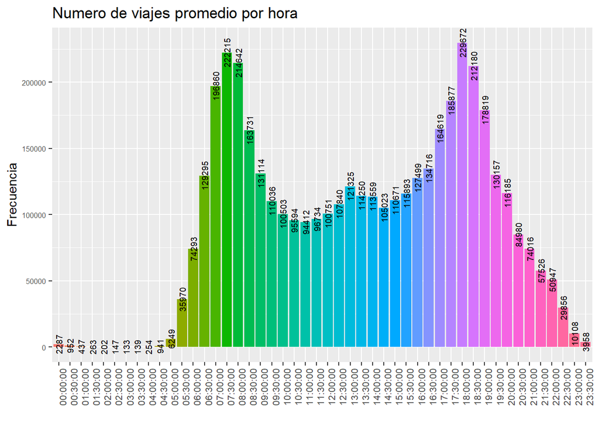

```r
library(dplyr)
library(ggplot2)
matriz_2019.08 %>%
  select(MediaHora, ViajeLaboralPromedio) %>%
  mutate(Hora = as.character(MediaHora)) %>%
  group_by(Hora) %>%
  summarise(total = round(sum(ViajeLaboralPromedio))) %>%
  arrange(Hora)%>%
  ggplot(aes(x=Hora, y=total, fill=Hora))+
  geom_bar(stat = 'identity')+
  geom_text(aes(label=total), size=2.5, angle = 90)+
  labs(x='', title = 'Numero de viajes promedio por hora', y="Frecuencia") +
  theme(axis.text.y = element_text(size=6),
        legend.position = 'none', axis.text.x = element_text(angle = 90, size = 8))
```

Grafico viajes promedio por hora:

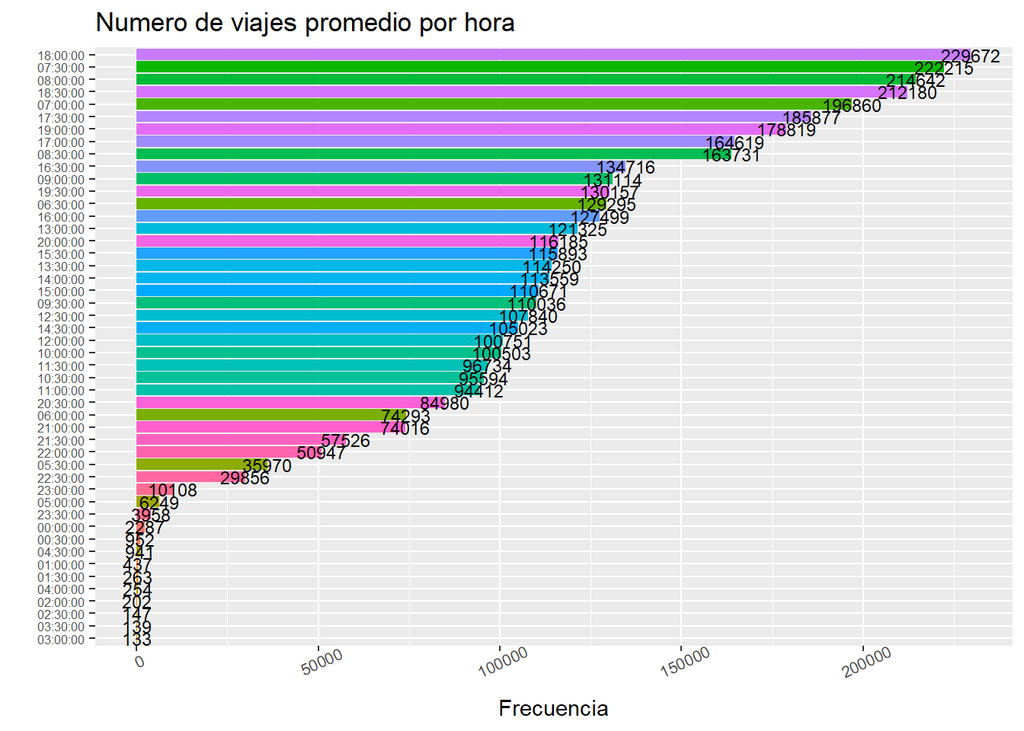

```r
library(dplyr)
library(ggplot2)
matriz_2019.08 %>%
  select(MediaHora, ViajeLaboralPromedio) %>%
  mutate(Hora = as.character(MediaHora)) %>%
  group_by(Hora) %>%
  summarise(total = round(sum(ViajeLaboralPromedio))) %>%
  arrange(-total)%>%
  ggplot(aes(x=reorder(Hora,total), y=total, fill=Hora))+
  geom_bar(stat = 'identity')+
  geom_text(aes(label=total), size=3)+
  labs(x='', title = 'Numero de viajes promedio por hora', y="Frecuencia") +
  theme(axis.text.y = element_text(size=6),
        legend.position = 'none', axis.text.x = element_text(angle = 25, size = 8)) +
  coord_flip()
```

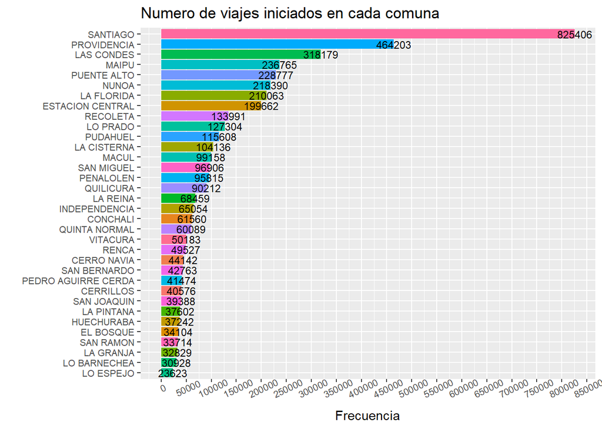

```r
matriz_2019.08 %>%   # Año 2010 y solo comunas
  group_by(ComunaSubida) %>%                       # Agrupamos por "muerto", "leve", etc
  summarise(total = round(sum(ViajeLaboralPromedio))) %>%              # Creamos una nueva columna a partir de cada grupo, llamada "total"
  arrange(-total)%>%
  ggplot(aes(x=reorder(ComunaSubida,total), y=total, fill= ComunaSubida))+
  geom_bar(stat = 'identity')+
  geom_text(aes(label=total), size=3)+
  labs(x='', title = 'Numero de viajes iniciados en cada comuna', y="Frecuencia") +
  theme(axis.text.y = element_text(size=8),
        legend.position = 'none', axis.text.x = element_text(angle = 25, size = 8)) +
  coord_flip()+
  scale_y_continuous(breaks = seq(0,900000,by=50000))
```

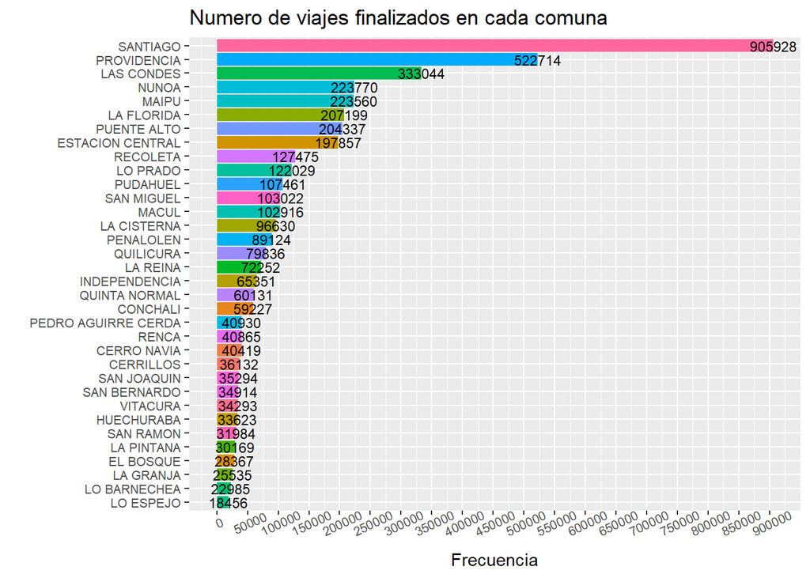

```r
matriz_2019.08 %>%   # Año 2010 y solo comunas
  group_by(ComunaBajada) %>%                       # Agrupamos por "muerto", "leve", etc
  summarise(total = round(sum(ViajeLaboralPromedio))) %>%              # Creamos una nueva columna a partir de cada grupo, llamada "total"
  arrange(-total)%>%
  ggplot(aes(x=reorder(ComunaBajada,total), y=total, fill= ComunaBajada))+
  geom_bar(stat = 'identity')+
  geom_text(aes(label=total), size=3)+
  labs(x='', title = 'Numero de viajes finalizados en cada comuna', y="Frecuencia") +
  theme(axis.text.y = element_text(size=8),
        legend.position = 'none', axis.text.x = element_text(angle = 25, size = 8)) +
  coord_flip()+
  scale_y_continuous(breaks = seq(0,900000,by=50000))
```

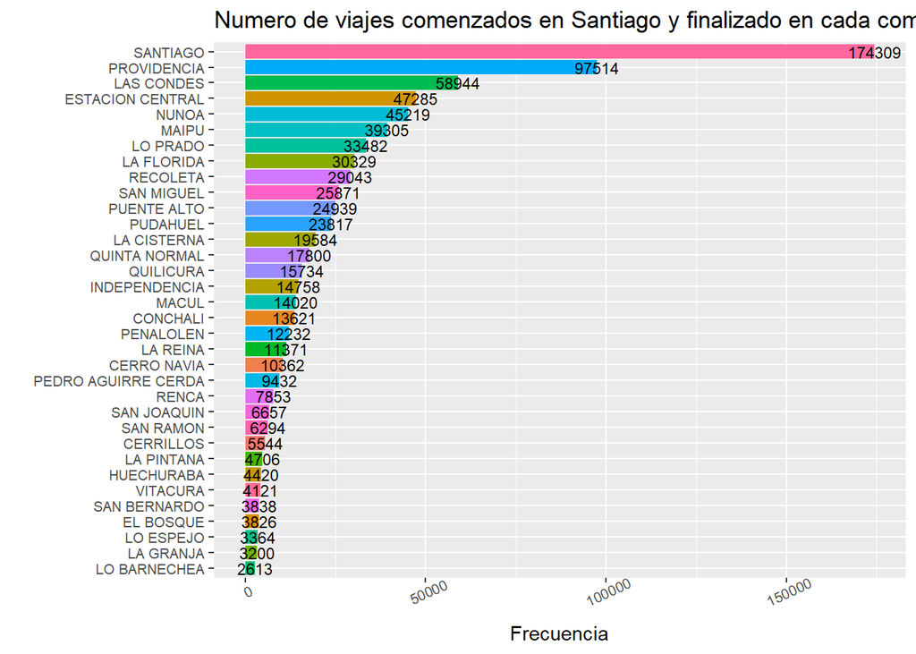

```r
matriz_2019.08 %>%   # Año 2010 y solo comunas
  filter(ComunaSubida=="SANTIAGO")%>%
  group_by(ComunaBajada) %>%                       # Agrupamos por "muerto", "leve", etc
  summarise(total = round(sum(ViajeLaboralPromedio))) %>%              # Creamos una nueva columna a partir de cada grupo, llamada "total"
  arrange(-total)%>%
  ggplot(aes(x=reorder(ComunaBajada,total), y=total, fill= ComunaBajada))+
  geom_bar(stat = 'identity')+
  geom_text(aes(label=total), size=3)+
  labs(x='', title = 'Numero de viajes comenzados en Santiago y finalizado en cada comuna', y="Frecuencia") +
  theme(axis.text.y = element_text(size=8),
        legend.position = 'none', axis.text.x = element_text(angle = 25, size = 8), plot.title = element_text(size = 13)) +
  coord_flip()+
  scale_y_continuous(breaks = seq(0,900000,by=50000))
```

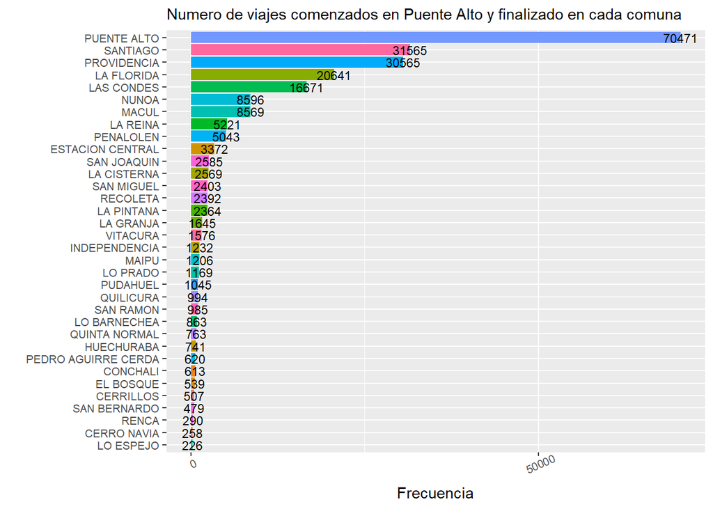

```r
matriz_2019.08 %>%   # Año 2010 y solo comunas
  filter(ComunaSubida=="PUENTE ALTO")%>%
  group_by(ComunaBajada) %>%                       # Agrupamos por "muerto", "leve", etc
  summarise(total = round(sum(ViajeLaboralPromedio))) %>%              # Creamos una nueva columna a partir de cada grupo, llamada "total"
  arrange(-total)%>%
  ggplot(aes(x=reorder(ComunaBajada,total), y=total, fill= ComunaBajada))+
  geom_bar(stat = 'identity')+
  geom_text(aes(label=total), size=3)+
  labs(x='', title = 'Numero de viajes comenzados en Puente Alto y finalizado en cada comuna', y="Frecuencia") +
  theme(axis.text.y = element_text(size=8),
        legend.position = 'none', axis.text.x = element_text(angle = 25, size = 8), plot.title = element_text(size = 11)) +
  coord_flip()+
  scale_y_continuous(breaks = seq(0,900000,by=50000))
```

## Graficos dataset viajes_encuesta

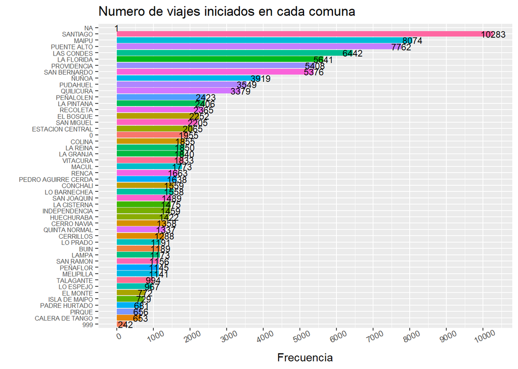

```r
viajes_encuesta %>%   # Año 2010 y solo comunas
  group_by(ComunaOrigen) %>%                       # Agrupamos por "muerto", "leve", etc
  summarise(total = n()) %>%              # Creamos una nueva columna a partir de cada grupo, llamada "total"
  arrange(-total)%>%
  ggplot(aes(x=reorder(ComunaOrigen,total), y=total, fill= ComunaOrigen))+
  geom_bar(stat = 'identity')+
  geom_text(aes(label=total), size=3)+
  labs(x='', title = 'Numero de viajes iniciados en cada comuna', y="Frecuencia") +
  theme(axis.text.y = element_text(size=6),
        legend.position = 'none', axis.text.x = element_text(angle = 25, size = 8)) +
  coord_flip()+
  scale_y_continuous(breaks = seq(0,15000,by=1000))
```

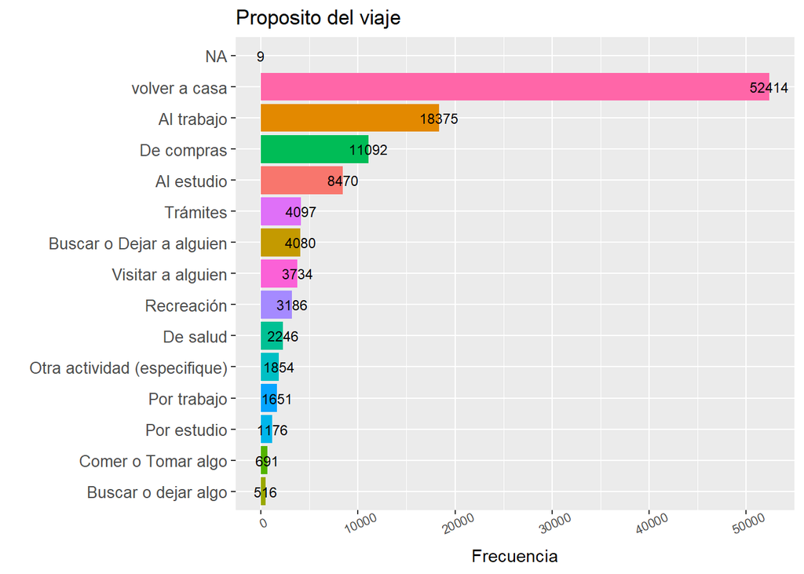

```r
viajes_encuesta %>%   # Año 2010 y solo comunas
  group_by(Proposito) %>%                       # Agrupamos por "muerto", "leve", etc
  summarise(total = n()) %>%              # Creamos una nueva columna a partir de cada grupo, llamada "total"
  arrange(-total)%>%
  ggplot(aes(x=reorder(Proposito,total), y=total, fill= Proposito))+
  geom_bar(stat = 'identity')+
  geom_text(aes(label=total), size=3)+
  labs(x='', title = 'Proposito del viaje', y="Frecuencia") +
  theme(axis.text.y = element_text(size=10),
        legend.position = 'none', axis.text.x = element_text(angle = 25, size = 8)) +
  coord_flip()+
  scale_y_continuous(breaks = seq(0,60000,by=10000))
```

## Graficos dataset hogares_encuesta

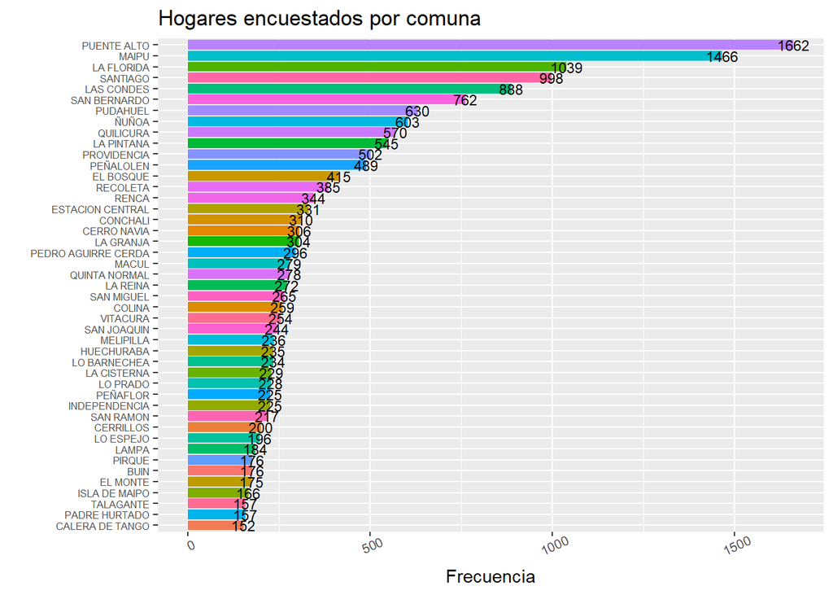

```r
hogares_encuesta %>%   # Año 2010 y solo comunas
  group_by(Comuna) %>%                       # Agrupamos por "muerto", "leve", etc
  summarise(total = n()) %>%              # Creamos una nueva columna a partir de cada grupo, llamada "total"
  arrange(-total)%>%
  ggplot(aes(x=reorder(Comuna,total), y=total, fill= Comuna))+
  geom_bar(stat = 'identity')+
  geom_text(aes(label=total), size=3)+
  labs(x='', title = 'Hogares encuestados por comuna', y="Frecuencia") +
  theme(axis.text.y = element_text(size=6),
        legend.position = 'none', axis.text.x = element_text(angle = 25, size = 8)) +
  coord_flip()+
  scale_y_continuous(breaks = seq(0,2000,by=500))
```

## Graficos dataset personas_encuesta

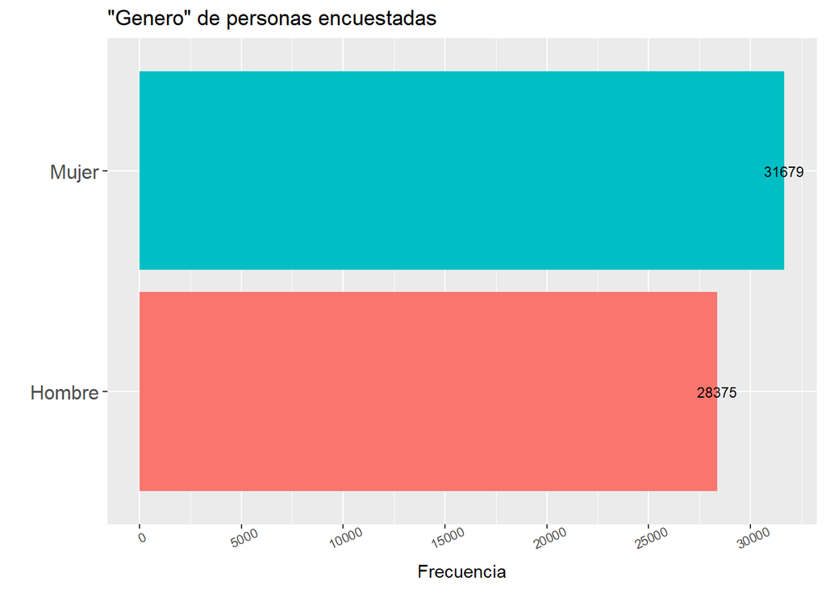

```r
personas_encuesta %>%   # Año 2010 y solo comunas
  group_by(Sexo) %>%                       # Agrupamos por "muerto", "leve", etc
  summarise(total = n()) %>%              # Creamos una nueva columna a partir de cada grupo, llamada "total"
  arrange(-total)%>%
  ggplot(aes(x=reorder(Sexo,total), y=total, fill= Sexo))+
  geom_bar(stat = 'identity')+
  geom_text(aes(label=total), size=3)+
  labs(x='', title = '"Genero" de personas encuestadas', y="Frecuencia") +
  theme(axis.text.y = element_text(size=12),
        legend.position = 'none', axis.text.x = element_text(angle = 25, size = 8)) +
  coord_flip()+
  scale_y_continuous(breaks = seq(0,32000,by=5000))
```

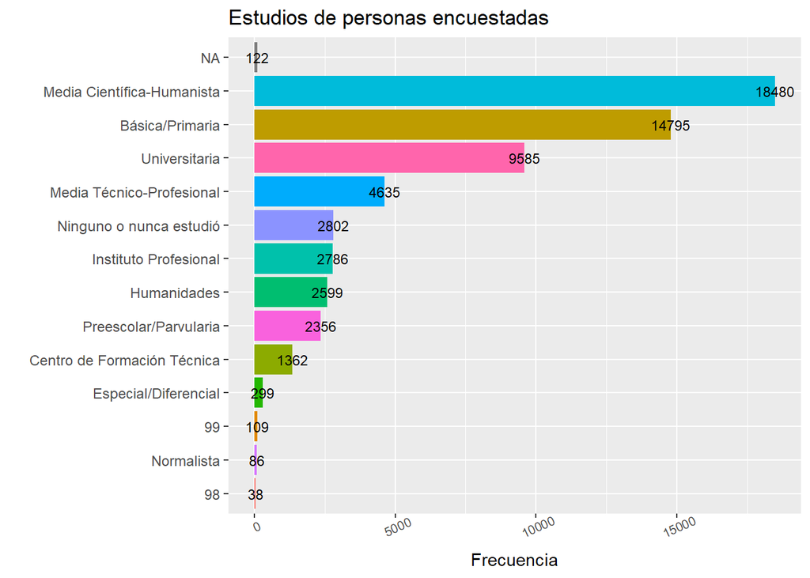

```r
personas_encuesta %>%   # Año 2010 y solo comunas
  group_by(Estudios) %>%                       # Agrupamos por "muerto", "leve", etc
  summarise(total = n()) %>%              # Creamos una nueva columna a partir de cada grupo, llamada "total"
  arrange(-total)%>%
  ggplot(aes(x=reorder(Estudios,total), y=total, fill= Estudios))+
  geom_bar(stat = 'identity')+
  geom_text(aes(label=total), size=3)+
  labs(x='', title = 'Estudios de personas encuestadas', y="Frecuencia") +
  theme(axis.text.y = element_text(size=9),
        legend.position = 'none', axis.text.x = element_text(angle = 25, size = 8)) +
  coord_flip()+
  scale_y_continuous(breaks = seq(0,32000,by=5000))
```

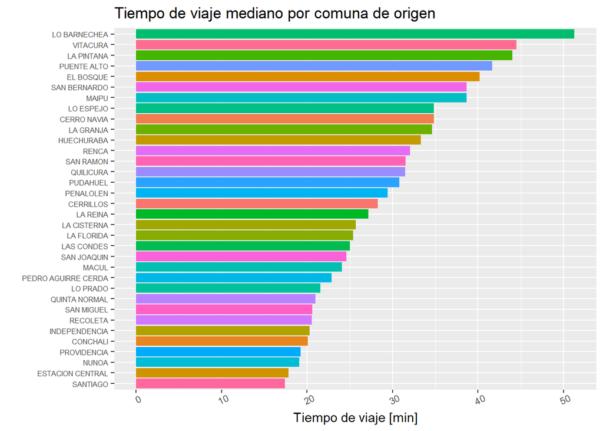

```r
viajeslaboral_2020 %>%
  filter(!is.na(tviaje_seg)) %>%
  filter(!is.na(comunasubida)) %>%
  group_by(comunasubida) %>%
  summarise(median_time = median(tviaje_seg/60.)) %>%
  ggplot(aes(x=reorder(comunasubida, median_time), y=median_time, fill=comunasubida)) +
  geom_bar(stat='identity') +
  labs(y='Tiempo de viaje [min]', title = 'Tiempo de viaje mediano por comuna de origen', x="") +
  theme(axis.text.y = element_text(size=6),
        legend.position = 'none', axis.text.x = element_text(angle = 25, size = 8)) +
  coord_flip()
```

# Confeccion de dataset

A continuacion se reordenan los datos de las matrices de viajes para tener solo 4 dataframes con la informacion de las comunas de 4 sectores.

```r
# Comunas segun sector, en base a la distribucion de las fiscalias metropolitanas
comunas_centronorte <- c('Santiago', 'Estacion Central', 'Quinta Normal', 'Independencia', 'Recoleta', 'Cerro Navia', 'Lo Prado', 'Renca', 'Conchali', 'Quilicura', 'Huechuraba', 'Colina', 'Lampa', 'Til Til')
comunas_sur <- c('El Bosque', 'La Cisterna', 'La Granja', 'La Pintana', 'Lo Espejo', 'Pedro Aguirre Cerda', 'Puente Alto', 'San Joaquin', 'San Miguel', 'San Ramon', 'Pirque', 'San Jose de Maipo')
comunas_oriente <- c('Las Condes', 'Vitacura', 'Lo Barnechea', 'La Reina', 'Nunoa', 'La Florida', 'Macul', 'Penalolen')
comunas_occidente <- c('Maipu', 'Cerrillos', 'Pudahuel', 'San Bernardo', 'Talagante', 'Melipilla', 'Curacavi')

comunas_centronorte <- toupper(comunas_centronorte)
comunas_sur <- toupper(comunas_sur)
comunas_oriente <- toupper(comunas_oriente)
comunas_occidente <- toupper(comunas_occidente)
```

```r
# Añadir una columna del año de los datos
matriz_2019.08$Año<- rep(2019,nrow(matriz_2019.08))
matriz_2018.04$Año<- rep(2018,nrow(matriz_2018.04))
matriz_2017.04$Año<- rep(2017,nrow(matriz_2017.04))
matriz_2016.05$Año<- rep(2016,nrow(matriz_2016.05))
matriz_2015.04$Año<- rep(2015,nrow(matriz_2015.04))
matriz_2014.05$Año<- rep(2014,nrow(matriz_2014.05))
matriz_2013.04$Año<- rep(2013,nrow(matriz_2013.04))
matriz_2012.04$Año<- rep(2012,nrow(matriz_2012.04))
matriz_2011.04$Año<- rep(2011,nrow(matriz_2011.04))
```

```r
# se juntan los datos de las comunas centronorte
matriz_centronorte <- bind_rows(filter(matriz_2019.08, ComunaSubida %in% comunas_centronorte),
                       filter(matriz_2018.04[, (names(matriz_2018.04) %in% names(matriz_2019.08))], ComunaSubida %in% comunas_centronorte),
                       filter(matriz_2017.04[, (names(matriz_2017.04) %in% names(matriz_2019.08))], ComunaSubida %in% comunas_centronorte),
                       filter(matriz_2016.05[, (names(matriz_2016.05) %in% names(matriz_2019.08))], ComunaSubida %in% comunas_centronorte),
                       filter(matriz_2015.04[, (names(matriz_2015.04) %in% names(matriz_2019.08))], ComunaSubida %in% comunas_centronorte),
                       filter(matriz_2014.05[, (names(matriz_2014.05) %in% names(matriz_2019.08))], ComunaSubida %in% comunas_centronorte),
                       filter(matriz_2013.04[, (names(matriz_2013.04) %in% names(matriz_2019.08))], ComunaSubida %in% comunas_centronorte),
                       filter(matriz_2012.04[, (names(matriz_2012.04) %in% names(matriz_2019.08))], ComunaSubida %in% comunas_centronorte),
                       filter(matriz_2011.04[, (names(matriz_2011.04) %in% names(matriz_2019.08))], ComunaSubida %in% comunas_centronorte))
head(matriz_centronorte,10)
```

```
## # A tibble: 10 x 11
##    ComunaSubida ComunaBajada MediaHora ViajeLaboralPro~ Viajes1Etapa
##    <chr>        <chr>        <time>               <dbl>        <dbl>
##  1 ESTACION CE~ MAIPU        00'00"              11.9         10.1
##  2 ESTACION CE~ PUDAHUEL     00'00"               6.50         4.69
##  3 ESTACION CE~ ESTACION CE~ 00'00"              16.6         16.2
##  4 ESTACION CE~ LO PRADO     00'00"               6.50         6.50
##  5 ESTACION CE~ CERRO NAVIA  00'00"               1.80         1.44
##  6 ESTACION CE~ RENCA        00'00"               0.722        0
##  7 ESTACION CE~ LO BARNECHEA 00'00"               0.722        0
##  8 ESTACION CE~ QUILICURA    00'00"               0.361        0
##  9 ESTACION CE~ PROVIDENCIA  00'00"               5.06         5.06
## 10 ESTACION CE~ LA REINA     00'00"               0.722        0.361
## # ... with 6 more variables: Viajes2Etapas <dbl>, Viajes3Etapas <dbl>,
## #   ViajesUsanMetro <dbl>, ViajesSoloMetro <dbl>, ViajesSoloBus <dbl>,
## #   Año <dbl>
```

```r
# se juntan los datos de las comunas del sur
matriz_sur <- bind_rows(filter(matriz_2019.08, ComunaSubida %in% comunas_sur),
                       filter(matriz_2018.04[, (names(matriz_2018.04) %in% names(matriz_2019.08))], ComunaSubida %in% comunas_sur),
                       filter(matriz_2017.04[, (names(matriz_2017.04) %in% names(matriz_2019.08))], ComunaSubida %in% comunas_sur),
                       filter(matriz_2016.05[, (names(matriz_2016.05) %in% names(matriz_2019.08))], ComunaSubida %in% comunas_sur),
                       filter(matriz_2015.04[, (names(matriz_2015.04) %in% names(matriz_2019.08))], ComunaSubida %in% comunas_sur),
                       filter(matriz_2014.05[, (names(matriz_2014.05) %in% names(matriz_2019.08))], ComunaSubida %in% comunas_sur),
                       filter(matriz_2013.04[, (names(matriz_2013.04) %in% names(matriz_2019.08))], ComunaSubida %in% comunas_sur),
                       filter(matriz_2012.04[, (names(matriz_2012.04) %in% names(matriz_2019.08))], ComunaSubida %in% comunas_sur),
                       filter(matriz_2011.04[, (names(matriz_2011.04) %in% names(matriz_2019.08))], ComunaSubida %in% comunas_sur))

head(matriz_sur,10)
```

```
## # A tibble: 10 x 11
##    ComunaSubida ComunaBajada MediaHora ViajeLaboralPro~ Viajes1Etapa
##    <chr>        <chr>        <time>               <dbl>        <dbl>
##  1 SAN JOAQUIN  ESTACION CE~ 00'00"               0.275        0.275
##  2 SAN JOAQUIN  MACUL        00'00"               0.549        0.549
##  3 SAN JOAQUIN  SAN JOAQUIN  00'00"               1.10         1.10
##  4 SAN JOAQUIN  LA GRANJA    00'00"               0.824        0.824
##  5 SAN JOAQUIN  LA PINTANA   00'00"               0.275        0.275
##  6 SAN JOAQUIN  EL BOSQUE    00'00"               0.275        0
##  7 SAN JOAQUIN  PEDRO AGUIR~ 00'00"               0.275        0.275
##  8 SAN JOAQUIN  SANTIAGO     00'00"               0.275        0.275
##  9 SAN JOAQUIN  SAN MIGUEL   00'00"               0.275        0.275
## 10 SAN JOAQUIN  PENALOLEN    00'00"               0.275        0
## # ... with 6 more variables: Viajes2Etapas <dbl>, Viajes3Etapas <dbl>,
## #   ViajesUsanMetro <dbl>, ViajesSoloMetro <dbl>, ViajesSoloBus <dbl>,
## #   Año <dbl>
```

```r
# se juntan los datos de las comunas del occidente
matriz_occidente <- bind_rows(filter(matriz_2019.08, ComunaSubida %in% comunas_occidente),
                       filter(matriz_2018.04[, (names(matriz_2018.04) %in% names(matriz_2019.08))], ComunaSubida %in% comunas_occidente),
                       filter(matriz_2017.04[, (names(matriz_2017.04) %in% names(matriz_2019.08))], ComunaSubida %in% comunas_occidente),
                       filter(matriz_2016.05[, (names(matriz_2016.05) %in% names(matriz_2019.08))], ComunaSubida %in% comunas_occidente),
                       filter(matriz_2015.04[, (names(matriz_2015.04) %in% names(matriz_2019.08))], ComunaSubida %in% comunas_occidente),
                       filter(matriz_2014.05[, (names(matriz_2014.05) %in% names(matriz_2019.08))], ComunaSubida %in% comunas_occidente),
                       filter(matriz_2013.04[, (names(matriz_2013.04) %in% names(matriz_2019.08))], ComunaSubida %in% comunas_occidente),
                       filter(matriz_2012.04[, (names(matriz_2012.04) %in% names(matriz_2019.08))], ComunaSubida %in% comunas_occidente),
                       filter(matriz_2011.04[, (names(matriz_2011.04) %in% names(matriz_2019.08))], ComunaSubida %in% comunas_occidente))

head(matriz_occidente,10)
```

```
## # A tibble: 10 x 11
##    ComunaSubida ComunaBajada MediaHora ViajeLaboralPro~ Viajes1Etapa
##    <chr>        <chr>        <time>               <dbl>        <dbl>
##  1 MAIPU        MAIPU        00'00"             103.          95.9
##  2 MAIPU        PUDAHUEL     00'00"               0.372        0.372
##  3 MAIPU        ESTACION CE~ 00'00"               7.06         5.95
##  4 MAIPU        LO PRADO     00'00"               0.744        0
##  5 MAIPU        CERRO NAVIA  00'00"               0.372        0
##  6 MAIPU        QUILICURA    00'00"               0.372        0
##  7 MAIPU        NUNOA        00'00"               0.372        0.372
##  8 MAIPU        LAS CONDES   00'00"               0.744        0.372
##  9 MAIPU        LO ESPEJO    00'00"               0.372        0.372
## 10 MAIPU        CERRILLOS    00'00"               1.86         1.86
## # ... with 6 more variables: Viajes2Etapas <dbl>, Viajes3Etapas <dbl>,
## #   ViajesUsanMetro <dbl>, ViajesSoloMetro <dbl>, ViajesSoloBus <dbl>,
## #   Año <dbl>
```

```r
# se juntan los datos de las comunas del oriente
matriz_oriente <- bind_rows(filter(matriz_2019.08, ComunaSubida %in% comunas_oriente),
                       filter(matriz_2018.04[, (names(matriz_2018.04) %in% names(matriz_2019.08))], ComunaSubida %in% comunas_oriente),
                       filter(matriz_2017.04[, (names(matriz_2017.04) %in% names(matriz_2019.08))], ComunaSubida %in% comunas_oriente),
                       filter(matriz_2016.05[, (names(matriz_2016.05) %in% names(matriz_2019.08))], ComunaSubida %in% comunas_oriente),
                       filter(matriz_2015.04[, (names(matriz_2015.04) %in% names(matriz_2019.08))], ComunaSubida %in% comunas_oriente),
                       filter(matriz_2014.05[, (names(matriz_2014.05) %in% names(matriz_2019.08))], ComunaSubida %in% comunas_oriente),
                       filter(matriz_2013.04[, (names(matriz_2013.04) %in% names(matriz_2019.08))], ComunaSubida %in% comunas_oriente),
                       filter(matriz_2012.04[, (names(matriz_2012.04) %in% names(matriz_2019.08))], ComunaSubida %in% comunas_oriente),
                       filter(matriz_2011.04[, (names(matriz_2011.04) %in% names(matriz_2019.08))], ComunaSubida %in% comunas_oriente))

head(matriz_oriente,10)
```

```
## # A tibble: 10 x 11
##    ComunaSubida ComunaBajada MediaHora ViajeLaboralPro~ Viajes1Etapa
##    <chr>        <chr>        <time>               <dbl>        <dbl>
##  1 LO BARNECHEA PUDAHUEL     00'00"               1.38         0
##  2 LO BARNECHEA ESTACION CE~ 00'00"               0.921        0
##  3 LO BARNECHEA LO BARNECHEA 00'00"               1.38         0.921
##  4 LO BARNECHEA VITACURA     00'00"               0.461        0
##  5 LO BARNECHEA PROVIDENCIA  00'00"               0.461        0
##  6 LO BARNECHEA NUNOA        00'00"               0.461        0
##  7 LO BARNECHEA MACUL        00'00"               0.921        0
##  8 LO BARNECHEA LAS CONDES   00'00"               0.921        0.921
##  9 LO BARNECHEA SANTIAGO     00'00"               4.15         2.76
## 10 LO BARNECHEA RECOLETA     00'00"               0.461        0.461
## # ... with 6 more variables: Viajes2Etapas <dbl>, Viajes3Etapas <dbl>,
## #   ViajesUsanMetro <dbl>, ViajesSoloMetro <dbl>, ViajesSoloBus <dbl>,
## #   Año <dbl>
```

A continuacion se separan los datos del dataframe “hogares_encuesta” segun los sector ya señalados:

```r
hogares_centronorte <- filter(hogares_encuesta, Comuna %in% comunas_centronorte)
hogares_sur <- filter(hogares_encuesta, Comuna %in% comunas_sur)
hogares_occidente <- filter(hogares_encuesta, Comuna %in% comunas_occidente)
hogares_oriente <- filter(hogares_encuesta, Comuna %in% comunas_oriente)
```

A continuacion se separan los datos del dataframe “viajes_encuesta” segun los sector ya señalados:

```r
viajes_centronorte <- filter(viajes_encuesta, ComunaOrigen %in% comunas_centronorte)
viajes_sur <- filter(viajes_encuesta, ComunaOrigen %in% comunas_sur)
viajes_occidente <- filter(viajes_encuesta, ComunaOrigen %in% comunas_occidente)
viajes_oriente <- filter(viajes_encuesta, ComunaOrigen %in% comunas_oriente)
```

A continuacion se separan los datos del dataframe “personas_encuesta” segun los sector ya señalados:

```r
personas_centronorte <- filter(personas_encuesta, Hogar %in% hogares_centronorte$Hogar)
personas_sur <- filter(personas_encuesta, Hogar %in% hogares_sur$Hogar)
personas_occidente <- filter(personas_encuesta, Hogar %in% hogares_occidente$Hogar)
personas_oriente <- filter(personas_encuesta, Hogar %in% hogares_oriente$Hogar)
```

# Preguntas y Problemas

En base a la motivación y la exploración de los datos surgieron las siguientes preguntas:

-¿Es posible alargar/recortar el horario de algún recorrido?

-Si agregamos un recorrido (bus o metro) que realice el trayecto de A a B, ¿Cuánta gente utilizaría este nuevo servicio? ¿Como este nuevo servicio descongestionaría el resto de la red?

- Tener en consideración el factor de la gente que no paga, y que el añadir nuevos tramos ayudará a mejorar eso
- Predecir cantidad de viajes de grupos poblacionales según sexo, ingreso, estudios, residencia, entre otros.

**Mejora de Preguntas y problemas**

Se tiene que tomar en cuenta que se realizó una separación en los datos entre las comunas de centronorte, occidente, oriente y sur, en base a las distribuciones de las fiscalías metropolitanas.

- ¿Existen características específicas o diferenciables entre los sectores de la ciudad al momento de definir una ruta o medio para el transporte?
- ¿Es posible encontrar grupos de personas en estos mismos sectores?, ¿Serán homogeneos u heterogeneos?, ¿Y si se comparan los grupos entre sectores?
- ¿Se podrá predecir el sector o comuna de residencia de una persona con información de sus viajes, minimizando la información personal?
- ¿Cuál sería la información necesaria para la predicción anterior?
- ¿Es correcta la separación de las comunas para dar respuesta a las preguntas anteriores?, ¿Se podría hacer alguna mejora?

En una visión a nivel regional, se realizan las siguientes preguntas respecto al dataset de viajes_encuesta (Encuesta de Origen y Destino de Viajes Santiago 2012):

- ¿Dónde se concentran los destinos de viaje según el lugar de origen y la hora?

En tanto, se formuló una pregunta que tiene relación con los hábitos de las personas que respondieron la encuesta anterior.

- ¿Se puede predecir el propósito del viaje con los otros datos de la encuesta?

En esta pregunta se busca saber si es posible predecir el propósito de viaje de las distintas personas basado diversos parámetros como por ejemplo, la hora en la que se viaja, el origen al destino del cual se viaja, entre otros.

- De lo anterior, ¿cuáles son las características del dataset con mayor importancia a la hora de hacer una clasificación del propósito de viaje?

# Propuestas Experimentales

Para las preguntas asociadas a separar los datos por zona, se realizan las siguientes propuestas para la etapa experimental:

- A los dataframe que ya fueron separados por zonas o sectores, según las comunas, se le agregaran una columna a modo de etiqueta que señale esta misma zona. Este procedimiento es importante para la pregunta de predicción que se propuso.
- Pre-procesar los datos, ya que si bien se han eliminado columnas o filas segun la cantidad de datos NA o iguales a cero, aun seguimos teniendo información con estas características, por lo que se debe decidir si se seguirán eliminando, o reemplazar los valores a un promedio o algo similar, según corresponda.

De la misma forma, ya se han reemplazado valores numéricos a texto, como por ejemplo motivos de viajes o comunas, se debe evaluar deshacer esto para utilizarlos como atributos en las técnicas de predicción y/o clustering.

- Crear un gran dataset, para particionarlo y generar el conjunto de entrenamiento, prueba y validación, debido a la gran cantidad de observaciones que manejamos, una posibilidad es tomar muestras de cada zona para generar este dataset. También con esto ultimo se puede balancear los datos con respecto a las clases.
- Con este gran dataset se realizará una reducción de atributos o características, esto se llevara a cabo de dos formas, una forma simple utilizando la varianza y la correlación entre columnas, para no perder explicabilidad, y utilizando PCA, para hacer visualizaciones en a lo mas 3D como apoyo al análisis. Esto con el fin de comparar los resultados y seleccionar el mejor.
- Para responder la pregunta de predicción o clasificación, utilizaremos modelos de KNN y SVM, para luego realizar una comparación entre los modelos. También probaremos usando distintos subconjuntos de atributos, para trabajar la pregunta con relación a la información necesaria para clasificar.
- Para evaluar la calidad de la clasificación, utilizaremos las métricas tradicionales como F1, precision y recall, aplicando un particionado de 60-20-20 para entrenamiento, testeo y prueba respectivamente. Nuestra idea de esto es no sobre-ajustar el modelo y este aprenda de subsets de entrenamiento distintos.
- También aplicaremos técnicas de clustering para encontrar de manera natural si las características de nuestro dataset son suficientes para encontrar grupos dentro de esta 4 zonas definidas.
- Probaremos múltiples combinaciones en el número de clúster pero solo utilizando enfoques particionales, ya que contamos con muchos datos para hacer algo jerárquico, y seguir manteniendo la capacidad un análisis cualitativo en ese caso.
- También probaremos usando distintos subconjuntos de atributos al hacer clustering para evaluar si los ejemplos se agrupan de manera distinta cuando consideramos información diferente. Y luego comprar los resultados obtenidos para cada zona.
- Para evaluar los clusters, utilizaremos el enfoque visual así como también la estimación de métricas tales como cohesión y separación.

Por otra parte, para visualizar los destinos del viaje se realizan las siguientes pasos a seguir para la propuesta experimental:

Para el estudio de donde se concentran los viajes según la hora se propone aplicar el algoritmo de clustering DBSCAN a los datos de destino de viaje de la EOD 2012. Concretamente, separar los datos por la hora de inicio del viaje y para cada hora seleccionar los datos de coordenadas de destino y a estos datos aplicarle el algoritmo. Se determinarán los parámetros eps y MinPoints seleccionando tres horas y evaluando los clusters obtenidos usando k-means y evaluación visual. Luego, usando estos parámetros se puede correr el algoritmo para el resto de las horas y graficar los resultados en un mapa para poder visualizar y comparar donde se concentrar los destinos de los viajes según la hora. Para este último paso será necesario aplicarles una transformación a los datos de coordenadas, ya que estos corresponden a las coordenadas en la proyección UTM, que es apropiada para utilizar la distancia euclideana, pero no sirva para mostrar los datos en un mapa.

Para el caso análogo de donde se concentran los viajes según el origen se propone utilizar un método similar al descrito anteriormente, pero separando los datos por comuna de origen.

Se decidió utilizar el algoritmo DBSCAN porque a diferencia de los otros algoritmos de clustering estudiados en el curso no requiere asignar todos los puntos a algún cluster y por la naturaleza de los datos no todos pertenecen a algún cluster. Además, este algoritmo es resiliente ante el ruido y como se utilizará sobre dos dimensiones no va a presentar los problemas que puede tener este algoritmo con datos de alta dimensionalidad.

Respondiendo las ultimas preguntas, de predicción de propósito de viajes, se realizan los siguientes pasos para la propuesta experimental:

- De partida, se trabajará con el dataset viajes_encuesta, este dataset contiene las siguientes columnas:

```r
colnames(viajes_encuesta)
```

```
##  [1] "Hogar"               "Persona"             "Viaje"
##  [4] "Etapas"              "ComunaOrigen"        "ComunaDestino"
##  [7] "SectorOrigen"        "SectorDestino"       "ZonaOrigen"
## [10] "ZonaDestino"         "OrigenCoordX"        "OrigenCoordY"
## [13] "DestinoCoordX"       "DestinoCoordY"       "Proposito"
## [16] "PropositoAgregado"   "MediosUsados"        "ModoAgregado"
## [19] "ModoPriPub"          "ModoMotor"           "HoraIni"
## [22] "HoraFin"             "HoraMedia"           "TiempoViaje"
## [25] "TiempoMedio"         "Periodo"             "MinutosDespues"
## [28] "CuadrasDespues"      "FactorLaboralNormal" "CódigoTiempo"
```

- Se eliminan las columnas Hogar, Persona y Viaje debido a que poseen códigos distintos en cada caso, y solo aportan información del individuo, no del contexto general.
- Existen columnas que deben ser divididas por sector, o se debe crear una forma en cómo representar datos como las comunas de origen y destino, como los distintos paraderos. Se puede utiizar con una codificación one-hot, sin embargo, eso puede suponer un incremento en la dimensionalidad del dataset en más de 1000 features muy sparse. Lo anterior supondría la búsqueda de algun método alternativo para hacer un encoding de los datos. Una de las opciones es crear un feature embedding que relacione distintos lugares y cree un vector de menor dimensionalidad, tal como ocurre con los word embeddings.
- Debido a que el dataset posee 14 clases distintas, de cada uno de los propósitos distintos, y éstas están altamente desbalanceados, se pueden juntar algunas clases que son similares, por ejemplo, ‘Al trabajo’ con ‘Por trabajo’ y ‘recreación’ con ‘comer y tomar algo’, para disminuir tanto el numero como el desbalance de clases.
- Luego se manejan los NaN de diversas maneras. Si una columna tiene un numero exagerado de NaNs, directamente se elimina, y si no, se pueden realizar diversas técnicas de regularización, como reemplazar por -1.
- Se dividen los datos en entrenamiento, validación y testing en una proporción 60, 20 y 20.
- Para hacer un manejo de NaNs en situaciones particulares, es necesario primero normalizar algunas features a una distribuición uniforme, y luego aplicar alguna técnica de regularización de NaNs especifica. Nótese que esta normalización se realiza teniendo en cuenta los datos de entrenamiento, y se aplican las mismas transformaciones a los sets de validación y testing.
- Una vez limpios los datos, se propone utilizar como clasificador un random forest, o utilizar un multilayer perceptron en conjunto con feature embeddings.
- Por un lado, se elige entrenar un random forest porque es un clasificador simple, rapido de entrenar, y que puede responder la siguiente pregunta, ¿cuáles son las características del dataset con mayor importancia a la hora de hacer una clasificación del propósito de viaje?
- Por el otro, sería interesante comparar distintas métricas a la hora de clasificar con un modelo MLP. Eso si, la pregunta asociada a la importancia de las features probablemente no pueda ser contestada con este modelo.
- Se entrenan los modelos con los sets de entrenamiento, y se van validando los resultados para cada epoch en el caso del clasificador MLP con el set de validación. Y se extraen los resultados con el set de testing para ambos casos.
- Con los resultados anteriores se concluye respondiendo ambas preguntas.

# Contribucion de cada integrante

- **Joaquin Cubelli de Leon**: Limpieza menor a dataset de viajes_encuesta, postulacion de preguntas asociadas a predicción de propósito de viajes, importancia de características y la metodología asociada a resolución de éstas.
- **Luckas Diaz Renjifo**: Limpieza de los dataset correspondientes a las matrices de viajes de los años 2011 a 2018, propuestas para las mejoras en las preguntas y problemas a resolver, de la misma forma en propuestas para las propuestas experimentales. Tambien separar los datos con respecto a los sectores de las comunas.
- **Ricardo Lopez Diaz**: Participación en la discusión de las propuestas de problemas y preguntas, revisión ortográfica.
- **José Luis Romero**: Postulación de pregunta respecto a visualizacion por clusters de viajes, y su metodología asociada.
- **Andres Urrutia Aliaga**: Eliminación de dataset descartados, participación en la discusión de las propuestas de problemas y preguntas